# Enquesta Condicions de vida dels usuaris dels CSS

# 2. Análisis de datos - Exploratorio y Bivariable

## 2.1 Carga de datos y análisis exploratorio

```python
from scripts.utils import filter_variables

import pandas as pd
import numpy as np
import seaborn as sns
import matplotlib.pyplot as plt

df = pd.read_pickle('data_final/final_df.pkl')
print(df.shape)

df_mayores = df[df['Edad'] >= 65]
print(df_mayores.shape)
```

```
(6624, 143)
(1597, 143)
```

## 2.2 Graficas

```python
from scripts.plots import plot_bar, plot_box, plot_violin, plot_correlation_matrix
from scripts.plots import plot_scatter, plot_multiple_numeric, plot_stacked_bar_percentage, plot_stacked_bar_percentage_binary
```

#### Ejemplos

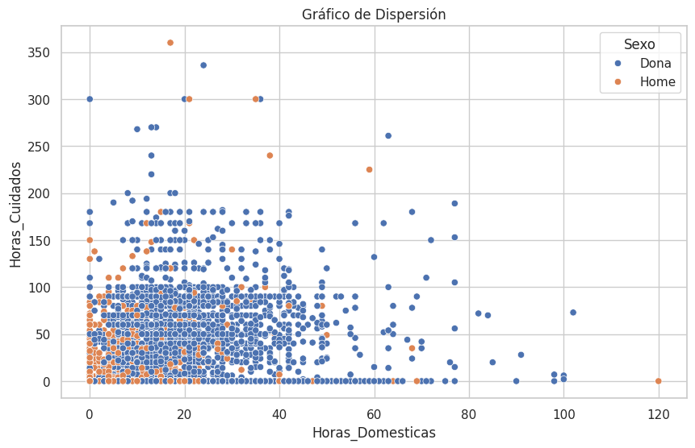

```python
plot_scatter(df, "Horas_Domesticas", "Horas_Cuidados", hue="Sexo")
```

```python
#sns.pairplot(df[["Sexo", "Edad", "Renda_Total_Llar", "Horas_Domesticas", "Horas_Cuidados", "Horas_Cocinar", "Horas_Comprar_Alim"]], diag_kind="kde", hue="Sexo")
```

### Graficas capítulo 4

#### Nivel de Estudios

```python
variables = ["Edad_Recod2", "Nivel_Estudios"]
df_filtrado = filter_variables(df[variables])
df_filtrado_mayores = filter_variables(df_mayores[variables])
```

```
Shape original del DataFrame: (6624, 2)
Shape del DataFrame después del filtrado: (6488, 2)
Shape original del DataFrame: (1597, 2)
Shape del DataFrame después del filtrado: (1565, 2)
```

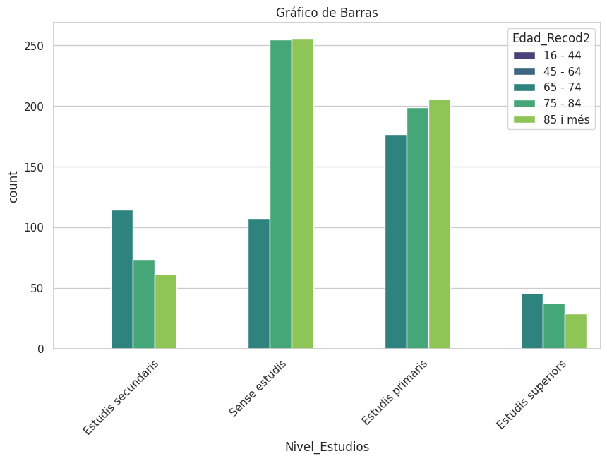

```python
plot_bar(df_filtrado_mayores, "Nivel_Estudios", hue="Edad_Recod2")
```

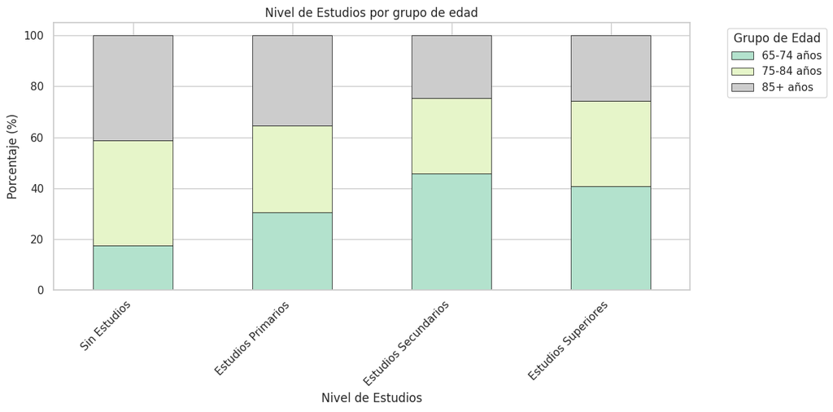

```python
# Diccionario para renombrar las variables en los ejes y la leyenda
rename_dict_vars = {
    "Nivel_Estudios": "Nivel de Estudios",
    "Edad_Recod2": "Grupo de Edad"
}

# Diccionario para renombrar los valores dentro de las variables categóricas
rename_dict_values = {
    "Estudis primaris": "Estudios Primarios",
    "Estudis secundaris": "Estudios Secundarios",
    "Estudis superiors": "Estudios Superiores",
    "Sense estudis": "Sin Estudios",
    "65 - 74": "65-74 años",
    "75 - 84": "75-84 años",
    "85 i més": "85+ años"
}

# Diccionario para ordenar manualmente las categorías en el eje X
custom_order_dict = {
    "Sin Estudios": 1,
    "Estudios Primarios": 2,
    "Estudios Secundarios": 3,
    "Estudios Superiores": 4
}

# Usar la función para generar el gráfico
plot_stacked_bar_percentage(df_filtrado_mayores, "Nivel_Estudios", "Edad_Recod2",
                            rename_dict_vars=rename_dict_vars,
                            rename_dict_values=rename_dict_values,
                            custom_order_dict=custom_order_dict,
                            title="Nivel de Estudios por grupo de edad",
                            cmap="Pastel2")
```

#### Origen geográfico

```python
variables = ["Edad_Recod", "Edad_Recod2", "Lugar_Nacimiento"]
df_filtrado = filter_variables(df[variables])
df_filtrado_mayores = filter_variables(df_mayores[variables])
```

```
Shape original del DataFrame: (6624, 3)
Shape del DataFrame después del filtrado: (6624, 3)
Shape original del DataFrame: (1597, 3)
Shape del DataFrame después del filtrado: (1597, 3)
```

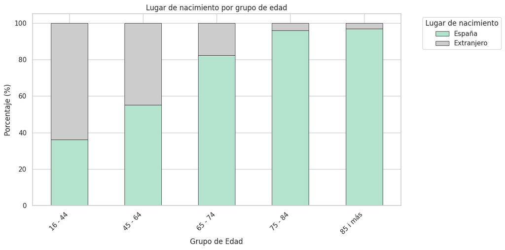

```python
rename_dict_vars = {
    "Lugar_Nacimiento": "Lugar de nacimiento",
    "Edad_Recod2": "Grupo de Edad"
}

rename_dict_values = {
    "Espanya": "España",
    "Estranger": "Extranjero",
    "85 i més": "85 i más"
}

plot_stacked_bar_percentage(df_filtrado, "Edad_Recod2", "Lugar_Nacimiento",
                            rename_dict_vars=rename_dict_vars,
                            rename_dict_values=rename_dict_values,
                            title="Lugar de nacimiento por grupo de edad")
```

### Graficas capítulo 5

#### 5.2 Necesidades personas mayores

```python
variables = ["Sexo", "Edad_Recod2", "Estado_Salud_Recod",  "Nivel_Estudios", "Ingresos_Equivalentes",
             "Visita_CSS_Econom", "Visita_CSS_Familia", "Visita_CSS_Depend", "Visita_CSS_Vivienda"]
df_filtrado = filter_variables(df[variables])
df_filtrado_mayores = filter_variables(df_mayores[variables])
```

```
Shape original del DataFrame: (6624, 9)
Shape del DataFrame después del filtrado: (6201, 9)
Shape original del DataFrame: (1597, 9)
Shape del DataFrame después del filtrado: (1321, 9)
```

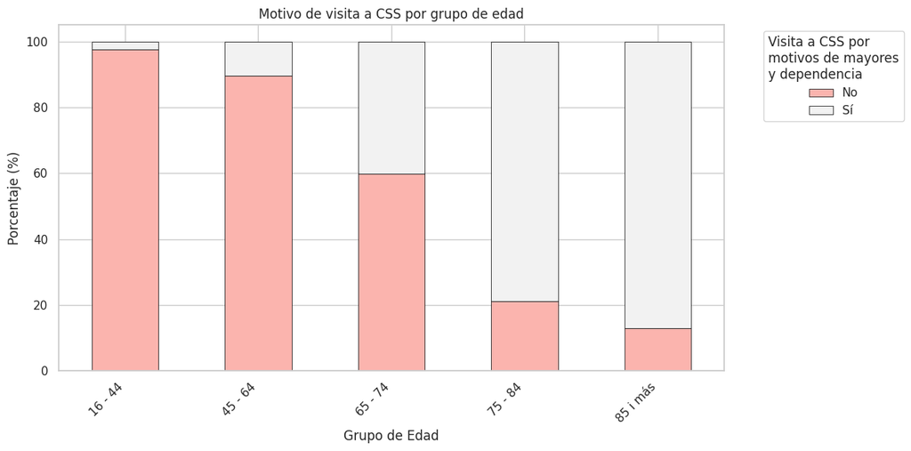

```python
# Diccionario para renombrar las variables en los ejes y la leyenda
rename_dict_vars = {
    "Nivel_Estudios": "Nivel de Estudios",
    "Edad_Recod2": "Grupo de Edad",
    "Visita_CSS_Depend": "Visita a CSS por\nmotivos de mayores\ny dependencia"
}

# Diccionario para renombrar los valores dentro de las variables categóricas
rename_dict_values = {
    "Estudis primaris": "Estudios Primarios",
    "Estudis secundaris": "Estudios Secundarios",
    "Estudis superiors": "Estudios Superiores",
    "Sense estudis": "Sin Estudios",
    "85 i més": "85 i más"
}

# Diccionario para ordenar manualmente las categorías en el eje X
# custom_order_dict = {
#     "Sin Estudios": 1,
#     "Estudios Primarios": 2,
#     "Estudios Secundarios": 3,
#     "Estudios Superiores": 4
# }

# Usar la función para generar el gráfico
plot_stacked_bar_percentage(df_filtrado, "Edad_Recod2", "Visita_CSS_Depend",
                            rename_dict_vars=rename_dict_vars,
                            rename_dict_values=rename_dict_values,
                            custom_order_dict=custom_order_dict,
                            title="Motivo de visita a CSS por grupo de edad",
                            cmap="Pastel1")
```

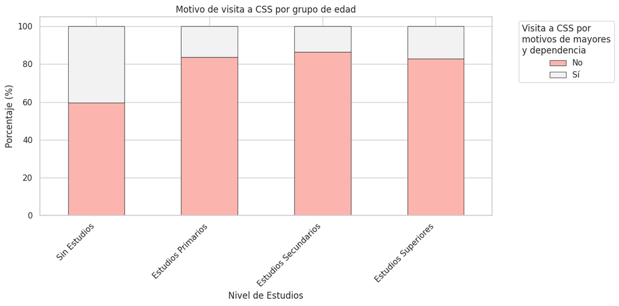

```python
# Usar la función para generar el gráfico
plot_stacked_bar_percentage(df_filtrado, "Nivel_Estudios", "Visita_CSS_Depend",
                            rename_dict_vars=rename_dict_vars,
                            rename_dict_values=rename_dict_values,
                            custom_order_dict=custom_order_dict,
                            title="Motivo de visita a CSS por grupo de edad",
                            cmap="Pastel1")
```

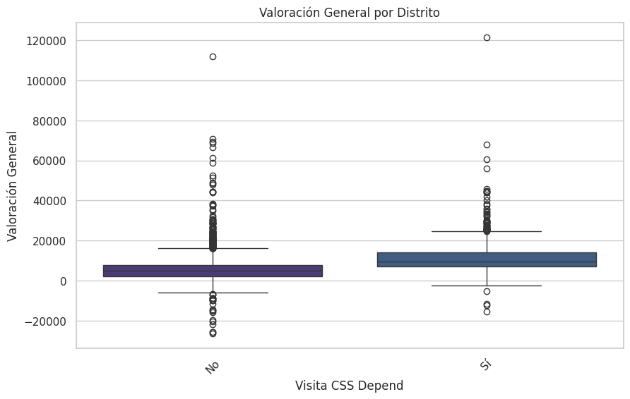

```python
plot_box(df_filtrado, "Visita_CSS_Depend", "Ingresos_Equivalentes", y_label="Valoración General", palette="viridis", title = "Valoración General por Distrito")
```

#### 5.3 Estado de Salud

```python
variables = ["Sexo", "Edad_Recod2", "Estado_Salud_Recod",  "Nivel_Estudios", "Problemas_Salud"]
df_filtrado = filter_variables(df[variables])
df_filtrado_mayores = filter_variables(df_mayores[variables])
```

```
Shape original del DataFrame: (6624, 5)
Shape del DataFrame después del filtrado: (6194, 5)
Shape original del DataFrame: (1597, 5)
Shape del DataFrame después del filtrado: (1316, 5)
```

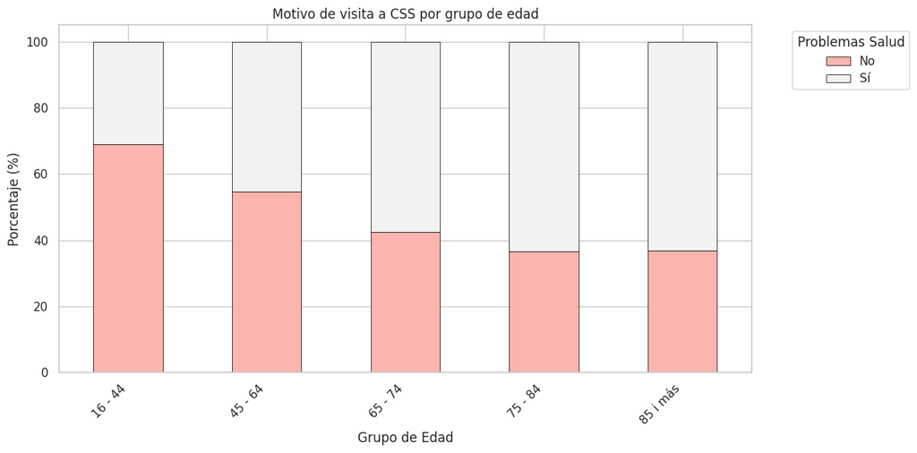

```python
# Diccionario para renombrar las variables en los ejes y la leyenda
rename_dict_vars = {
    "Nivel_Estudios": "Nivel de Estudios",
    "Edad_Recod2": "Grupo de Edad",
    "Visita_CSS_Depend": "Visita a CSS por\nmotivos de mayores\ny dependencia"
}

# Diccionario para renombrar los valores dentro de las variables categóricas
rename_dict_values = {
    "Estudis primaris": "Estudios Primarios",
    "Estudis secundaris": "Estudios Secundarios",
    "Estudis superiors": "Estudios Superiores",
    "Sense estudis": "Sin Estudios",
    "85 i més": "85 i más"
}

# Diccionario para ordenar manualmente las categorías en el eje X
# custom_order_dict = {
#     "Sin Estudios": 1,
#     "Estudios Primarios": 2,
#     "Estudios Secundarios": 3,
#     "Estudios Superiores": 4
# }

# Usar la función para generar el gráfico
plot_stacked_bar_percentage(df_filtrado, "Edad_Recod2", "Problemas_Salud",
                            rename_dict_vars=rename_dict_vars,
                            rename_dict_values=rename_dict_values,
                            custom_order_dict=custom_order_dict,
                            title="Motivo de visita a CSS por grupo de edad",
                            cmap="Pastel1")
```

#### Vulnerabilidad Económica

```python
# Diccionario de renombre de variables
rename_dict = {
    "Lavadora_Disponible": "Lavadora",
    "TV_Disponible": "Televisión",
    "Telefono_Disponible": "Teléfono",
    "Vater_Disponible": "Váter",
    "Ducha_Disponible": "Ducha",
    "Mala_Ventilacion": "Mala Ventilación",
    "Problemas_Estructura": "Problemas \nEstructurales",
    "Contaminacion_Medioambiental": "Contaminación\nMedioambiental",
    "Delincuencia_Vandalismo": "Delincuencia/\nVandalismo",
    "Vacaciones_Anual": "Vacaciones Anuales",
    "Gasto_Imprevisto_800": "Gasto Imprevisto\n (+800€)",
    "Comida_DosDias": "Comida 2 Días",
    "Temp_Caliente_Invierno": "Temperatura \nCaliente Invierno",
    "TarjetaCredito": "Tarjeta de Crédito",
    "Internet": "Internet en Casa",
    "PC_Disponible": "Ordenador Personal",
    "Coche": "Coche Disponible",
    "Goteras_Humedades": "Goteras o\n Humedades",
    "Escasez_Luz_Natural": "Escasez de\n Luz Natural",
    "Grietas_Paredes": "Grietas en Paredes",
    "Insectos_Ratas": "Insectos o Ratas",
    "Ruido_Vecinos": "Ruido de Vecinos",
}
```

```
Shape original del DataFrame: (6624, 13)
Shape del DataFrame después del filtrado: (6549, 13)
Shape original del DataFrame: (1597, 13)
Shape del DataFrame después del filtrado: (1567, 13)
```

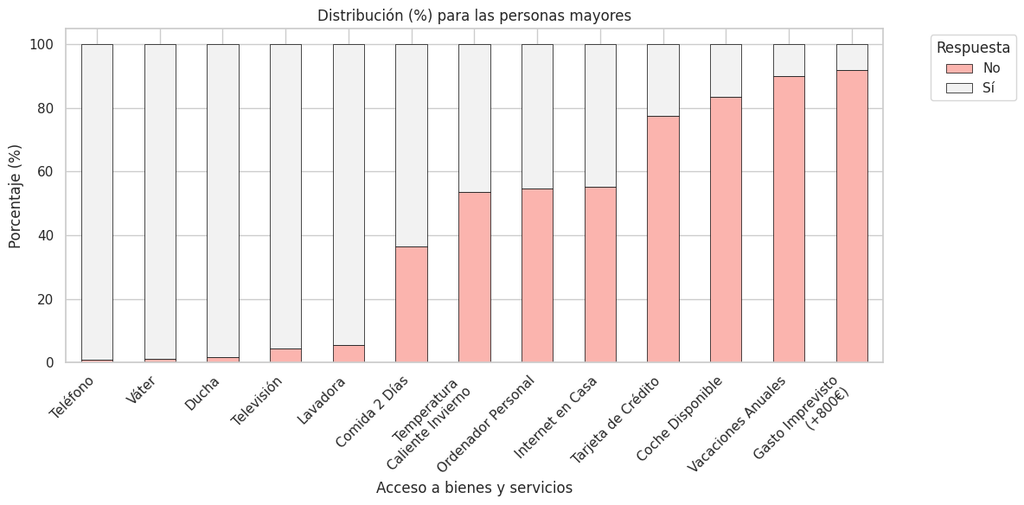

```python
# Lista de variables binarias
variables_acceso = [
    "Lavadora_Disponible", "TV_Disponible", "Telefono_Disponible", "Vater_Disponible", "Ducha_Disponible",
    "Vacaciones_Anual", "Gasto_Imprevisto_800",
    "Comida_DosDias", "Temp_Caliente_Invierno", "TarjetaCredito", "Internet", "PC_Disponible", "Coche"
]

df_filtrado = filter_variables(df[variables_acceso])
df_filtrado_mayores = filter_variables(df_mayores[variables_acceso])

# Uso de la función con el DataFrame
plot_stacked_bar_percentage_binary(df_filtrado, variables_acceso, rename_dict, x_label="Acceso a bienes y servicios", title="Distribución (%) para las personas mayores")
```

```
Shape original del DataFrame: (6624, 9)
Shape del DataFrame después del filtrado: (6341, 9)
Shape original del DataFrame: (1597, 9)
Shape del DataFrame después del filtrado: (1540, 9)
```

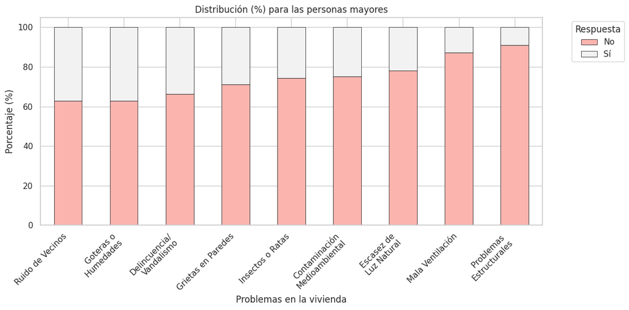

```python
variables_problemas = ["Mala_Ventilacion", "Problemas_Estructura", "Contaminacion_Medioambiental", "Delincuencia_Vandalismo",
                       "Goteras_Humedades", "Escasez_Luz_Natural", "Grietas_Paredes", "Insectos_Ratas", "Ruido_Vecinos"]

df_filtrado = filter_variables(df[variables_problemas])
df_filtrado_mayores = filter_variables(df_mayores[variables_problemas])

# Uso de la función con el DataFrame
plot_stacked_bar_percentage_binary(df_filtrado, variables_problemas, rename_dict, x_label="Problemas en la vivienda", title="Distribución (%) para las personas mayores")
```

```python
variables = ["Sexo", "Edad_Recod2", "Propietat_Habitatge"]

df_filtrado = filter_variables(df[variables])
df_filtrado_mayores = filter_variables(df_mayores[variables])
```

```
Shape original del DataFrame: (6624, 3)
Shape del DataFrame después del filtrado: (6619, 3)
Shape original del DataFrame: (1597, 3)
Shape del DataFrame después del filtrado: (1595, 3)
```

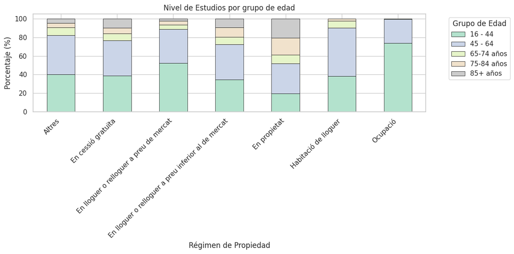

```python
# Diccionario para renombrar las variables en los ejes y la leyenda
rename_dict_vars = {
    "Propietat_Habitatge": "Régimen de Propiedad",
    "Edad_Recod2": "Grupo de Edad"
}

# Diccionario para renombrar los valores dentro de las variables categóricas
rename_dict_values = {
    "Estudis primaris": "Estudios Primarios",
    "Estudis secundaris": "Estudios Secundarios",
    "Estudis superiors": "Estudios Superiores",
    "Sense estudis": "Sin Estudios",
    "65 - 74": "65-74 años",
    "75 - 84": "75-84 años",
    "85 i més": "85+ años"
}

# Diccionario para ordenar manualmente las categorías en el eje X
custom_order_dict = {
    "Sin Estudios": 1,
    "Estudios Primarios": 2,
    "Estudios Secundarios": 3,
    "Estudios Superiores": 4
}

# Usar la función para generar el gráfico
plot_stacked_bar_percentage(df_filtrado, "Propietat_Habitatge", "Edad_Recod2",
                            rename_dict_vars=rename_dict_vars,
                            rename_dict_values=rename_dict_values,
                            custom_order_dict=custom_order_dict,
                            title="Nivel de Estudios por grupo de edad",
                            cmap="Pastel2")
```

#### Valoración Atención CSS

```python
variables_num = ['Valoracion_General', 'Valoracion_TiempoEspera', 'Valoracion_Facilidad', 'Valoracion_Horarios',
                 'Valoracion_Utilidad', 'Valoracion_Dedicacion', 'Valoracion_Intervencion', 'Valoracion_Respuesta', 'Valoracion_Profesionalidad',
                 'Valoracion_Comprension', 'Valoracion_Amabilidad', 'Valoracion_Intimidad']
                 #, 'Valoracion_Utilidad2', 'Valoracion_Gestion', 'Valoracion_Amabilidad2', 'Valoracion_Intimidad2']

variables_num2 = ['Millora_Autonomia', 'Millora_Anim', 'Sentimient_Companyia', 'Sentimient_Tranquilitat', 'Sentimient_Seguretat',
                  'Satisfaccio_Vital', 'Benefici_Familia']

variables_categ = [ #'Visita_CSS_Econom', 'Visita_CSS_Familia', 'Visita_CSS_Depend', 'Visita_CSS_Empleo', 'Visita_CSS_Vivienda',
                   'Sexo', 'Distrito']  #, 'Estado_Salud_Recod']

df_filtrado = filter_variables(df[variables_num + variables_num2 + variables_categ])
df_filtrado_mayores = filter_variables(df_mayores[variables_num + variables_num2 + variables_categ])
```

```
Shape original del DataFrame: (6624, 21)
Shape del DataFrame después del filtrado: (5922, 21)
Shape original del DataFrame: (1597, 21)
Shape del DataFrame después del filtrado: (1341, 21)
```

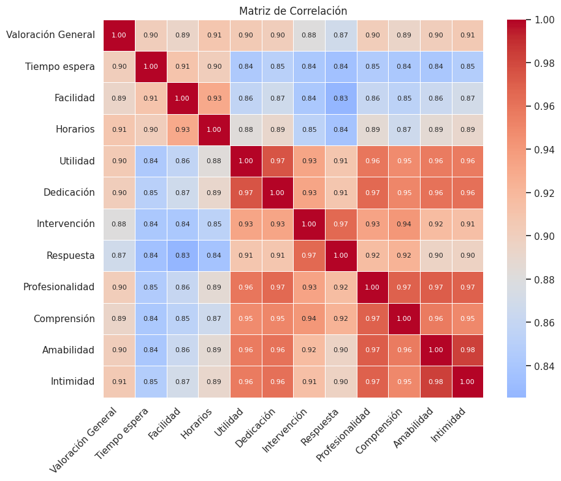

```python
# Diccionario de renombrado para limpiar nombres
rename_dict = {
    "Valoracion_General": "Valoración General",
    "Valoracion_TiempoEspera": "Tiempo espera",
    "Valoracion_Facilidad": "Facilidad",
    "Valoracion_Horarios": "Horarios",
    "Valoracion_Utilidad": "Utilidad",
    "Valoracion_Dedicacion": "Dedicación",
    "Valoracion_Intervencion": "Intervención",
    "Valoracion_Respuesta": "Respuesta",
    "Valoracion_Profesionalidad": "Profesionalidad",
    "Valoracion_Comprension": "Comprensión",
    "Valoracion_Amabilidad": "Amabilidad",
    "Valoracion_Intimidad": "Intimidad"
    # "Valoracion_Utilidad2": "Utilidad 2",
    # "Valoracion_Gestion": "Gestión",
    # "Valoracion_Amabilidad2": "Amabilidad 2",
    # "Valoracion_Intimidad2": "Intimidad 2"
}

plot_correlation_matrix(df_filtrado_mayores[variables_num], annot_size=8, rename_dict=rename_dict, cmap="coolwarm", center_value=0.88)
```

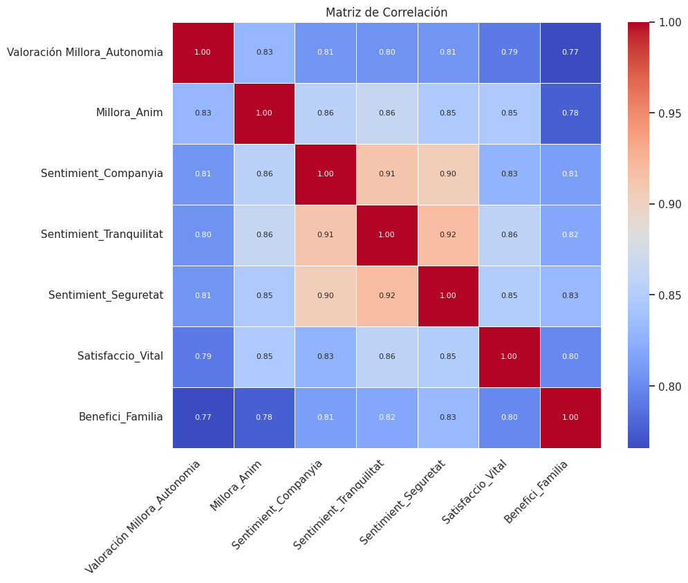

```python
# Diccionario de renombrado para limpiar nombres
rename_dict = {
    "Millora_Autonomia": "Valoración Millora_Autonomia",
    "Millora_Anim": "Millora_Anim",
    "Sentimient_Companyia": "Sentimient_Companyia",
    "Sentimient_Tranquilitat": "Sentimient_Tranquilitat",
    "Sentimient_Seguretat": "Sentimient_Seguretat",
    "Satisfaccio_Vital": "Satisfaccio_Vital",
    "Benefici_Familia": "Benefici_Familia",
}

plot_correlation_matrix(df_filtrado[variables_num2], annot_size=8, rename_dict=rename_dict, cmap="coolwarm")
```

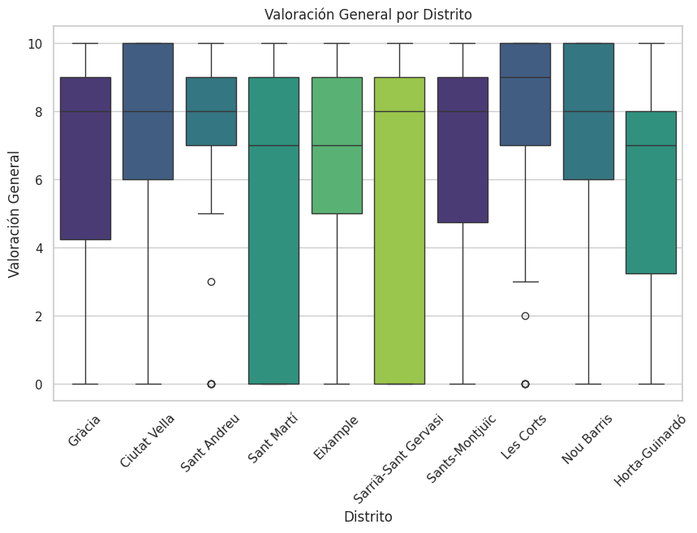

```python
plot_box(df_filtrado_mayores, "Distrito", "Valoracion_General", y_label="Valoración General", palette="viridis", title = "Valoración General por Distrito")
```

#### Tareas domésticas (dedicación horaria)

```python
variables = ["Sexo", "Horas_Domesticas", "Horas_Cuidados", "Horas_Cocinar", "Horas_Comprar_Alim", "Horas_Reparaciones", "Horas_Admin_Dinero"]
df_filtrado = filter_variables(df[variables])
df_filtrado_mayores = filter_variables(df_mayores[variables])
```

```
Shape original del DataFrame: (6624, 7)
Shape del DataFrame después del filtrado: (6624, 7)
Shape original del DataFrame: (1597, 7)
Shape del DataFrame después del filtrado: (1597, 7)
```

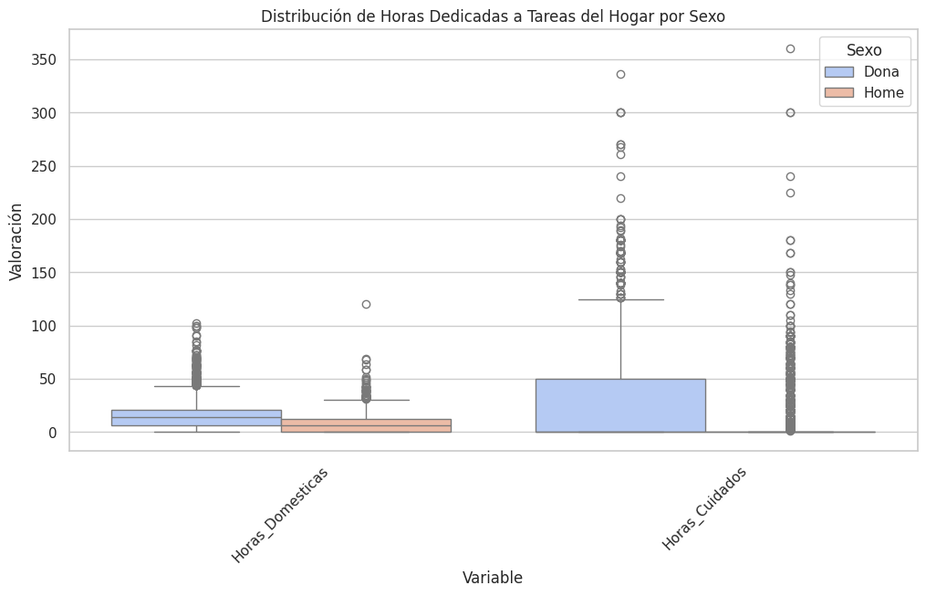

```python
plot_multiple_numeric(df_filtrado, ["Horas_Domesticas", "Horas_Cuidados"], "Sexo", plot_type="boxplot", title="Distribución de Horas Dedicadas a Tareas del Hogar por Sexo")
```

```
Shape original del DataFrame: (6624, 8)
Shape del DataFrame después del filtrado: (6467, 8)
Shape original del DataFrame: (1597, 8)
Shape del DataFrame después del filtrado: (1555, 8)
```

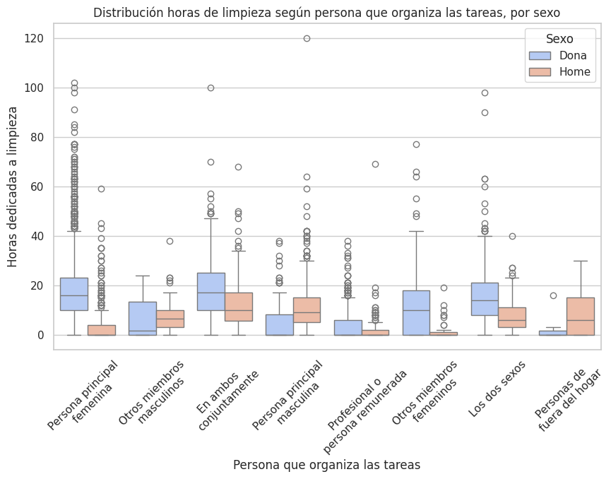

```python
variables = ["Sexo", "Tareas_Domesticas", "Horas_Domesticas", "Horas_Cuidados", "Horas_Cocinar", "Horas_Comprar_Alim", "Horas_Reparaciones", "Horas_Admin_Dinero"]
df_filtrado = filter_variables(df[variables])
df_filtrado_mayores = filter_variables(df_mayores[variables])

rename_dict = {
    "Fonamentalment en la persona principal masculina" : "Persona principal\n masculina",
    "Fonamentalment en la persona principal femenina" : "Persona principal\n femenina",
    "En ambdós conjuntament": "En ambos \nconjuntamente",
    "Un altre o diversos membres femenins de la llar" : "Otros miembros\n femeninos",
    "Un altre o diversos membres masculins de la llar" : "Otros miembros\n masculinos",
    "Tots o diversos membres de la llar d'ambdós sexes" : "Los dos sexos",
    "Professional o persona remunerada" : "Profesional o \npersona remunerada",
    "Una o diverses persones de fora de la llar (no remunerades)": "Personas de \nfuera del hogar",
}

df_filtrado["Tareas_Domesticas"] = df_filtrado["Tareas_Domesticas"].replace(rename_dict)
df_filtrado_mayores["Tareas_Domesticas"] = df_filtrado_mayores["Tareas_Domesticas"].replace(rename_dict)

#plot_box(df_filtrado, "Tareas_Domesticas", "Horas_Domesticas", hue="Sexo", title="")

plt.figure(figsize=(10, 6))
sns.boxplot(data=df_filtrado, x="Tareas_Domesticas", y="Horas_Domesticas", hue="Sexo", palette="coolwarm")
plt.xticks(rotation=45)
plt.title("Distribución horas de limpieza según persona que organiza las tareas, por sexo")
plt.xlabel("Persona que organiza las tareas")
plt.ylabel("Horas dedicadas a limpieza")
plt.show()
```

```
Shape original del DataFrame: (6624, 12)
Shape del DataFrame después del filtrado: (6624, 12)
Shape original del DataFrame: (1597, 12)
Shape del DataFrame después del filtrado: (1597, 12)
```

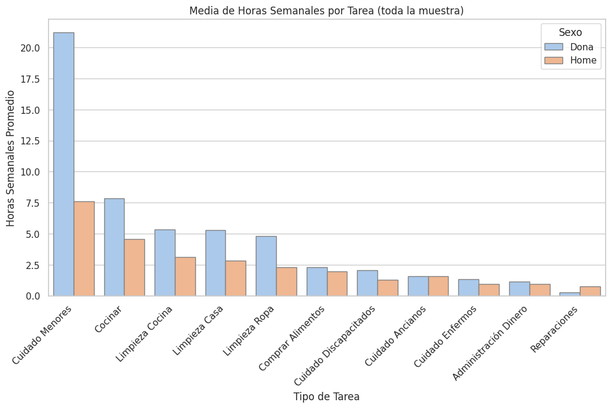

```python
import pandas as pd
import seaborn as sns
import matplotlib.pyplot as plt

# Lista de variables de horas dedicadas a cada tarea
variables = ["Horas_Limpieza_Ropa", 'Horas_Limpieza_Cocina', 'Horas_Limpieza_Casa',
             'Horas_Cocinar', 'Horas_Comprar_Alim', 'Horas_Reparaciones', 'Horas_Admin_Dinero',
             'Horas_Atencion_Ancianos', 'Horas_Atencion_Discapac', 'Horas_Atencion_Enfermos',
             'Horas_Atencion_Menores']
            #'Horas_Domesticas', 'Horas_Cuidados']

df_filtrado = filter_variables(df[variables + ["Sexo"]])
df_filtrado_mayores = filter_variables(df_mayores[variables + ["Sexo"]])

# Diccionario de renombre de las tareas
rename_dict = {
    "Horas_Limpieza_Ropa": "Limpieza Ropa",
    "Horas_Limpieza_Cocina": "Limpieza Cocina",
    "Horas_Limpieza_Casa": "Limpieza Casa",
    #"Horas_Domesticas": "Total Tareas Domésticas",
    "Horas_Cocinar": "Cocinar",
    "Horas_Comprar_Alim": "Comprar Alimentos",
    "Horas_Reparaciones": "Reparaciones",
    "Horas_Admin_Dinero": "Administración Dinero",
    "Horas_Atencion_Ancianos": "Cuidado Ancianos",
    "Horas_Atencion_Discapac": "Cuidado Discapacitados",
    "Horas_Atencion_Enfermos": "Cuidado Enfermos",
    "Horas_Atencion_Menores": "Cuidado Menores",
    #"Horas_Cuidados": "Total Cuidados"
}

# Calcular la media de horas por categoría (e.g., Sexo)
mean_hours = df_filtrado.groupby("Sexo")[variables].mean().reset_index()

# Transformamos a formato largo para Seaborn
df_long = mean_hours.melt(id_vars=["Sexo"], var_name="Tarea", value_name="Horas Promedio")

# Renombrar las tareas según el diccionario
df_long["Tarea"] = df_long["Tarea"].replace(rename_dict)

# Ordenar las tareas de mayor a menor dedicación
order = df_long.groupby("Tarea")["Horas Promedio"].sum().sort_values(ascending=False).index

# Graficar
plt.figure(figsize=(12, 6))
sns.barplot(data=df_long, x="Tarea", y="Horas Promedio", hue="Sexo", palette="pastel", order=order, edgecolor=".5")

# Ajustes de presentación
plt.xticks(rotation=45, ha="right")
plt.xlabel("Tipo de Tarea")
plt.ylabel("Horas Semanales Promedio")
plt.title("Media de Horas Semanales por Tarea (toda la muestra)")
plt.legend(title="Sexo")
plt.show()
```

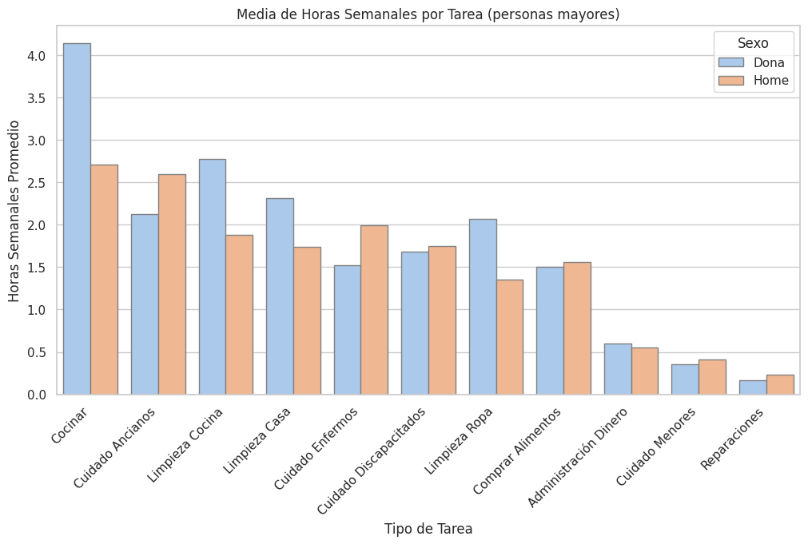

```python
# Calcular la media de horas por categoría (e.g., Sexo)
mean_hours = df_filtrado_mayores.groupby("Sexo")[variables].mean().reset_index()

# Transformamos a formato largo para Seaborn
df_long = mean_hours.melt(id_vars=["Sexo"], var_name="Tarea", value_name="Horas Promedio")

# Renombrar las tareas según el diccionario
df_long["Tarea"] = df_long["Tarea"].replace(rename_dict)

# Ordenar las tareas de mayor a menor dedicación
order = df_long.groupby("Tarea")["Horas Promedio"].sum().sort_values(ascending=False).index

# Graficar
plt.figure(figsize=(12, 6))
sns.barplot(data=df_long, x="Tarea", y="Horas Promedio", hue="Sexo", palette="pastel", order=order, edgecolor=".5")

# Ajustes de presentación
plt.xticks(rotation=45, ha="right")
plt.xlabel("Tipo de Tarea")
plt.ylabel("Horas Semanales Promedio")
plt.title("Media de Horas Semanales por Tarea (personas mayores)")
plt.legend(title="Sexo")
plt.show()
```

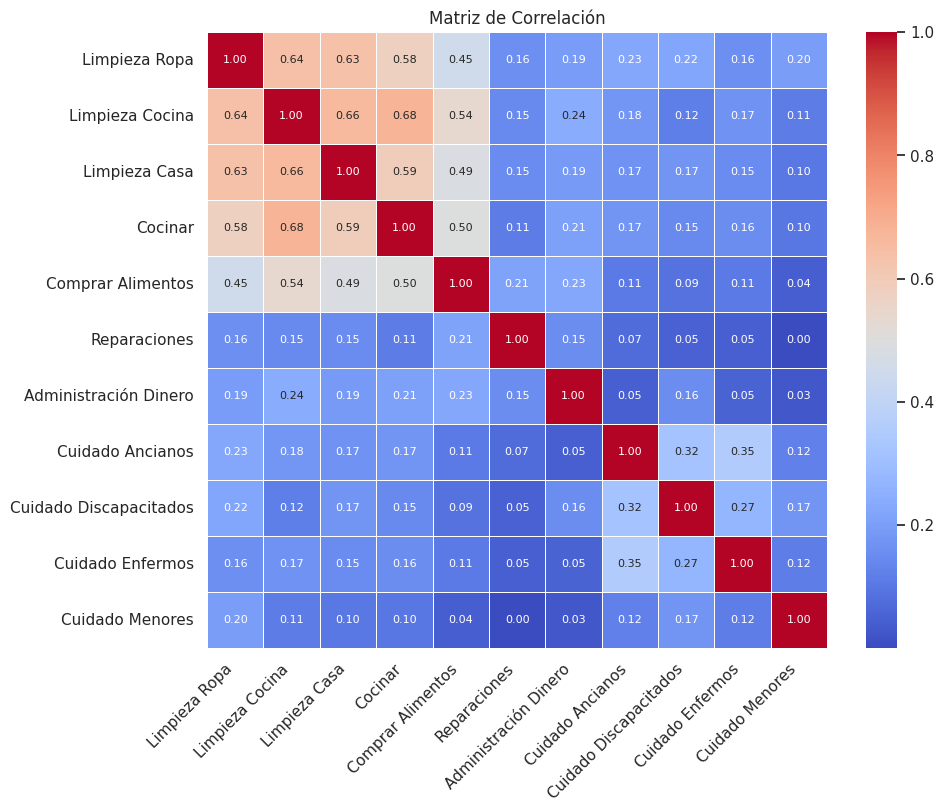

```python
plot_correlation_matrix(df_filtrado_mayores[variables], annot_size=8, rename_dict=rename_dict, cmap="coolwarm")
```

## 2.3 Tablas capítulo 4

```python
from scripts.tables import generar_tabla_frecuencias, analizar_cruce_bivariable, plot_table
from scripts.utils import filter_variables
```

### 2.3.1 Tipo de Hogar

#### Tabla Frecuencias de Tipo de Hogar

Te pongo las tres variables de tipo de hogar. `Tipo_Hogar` es la que creé yo y `Tipo_Hogar1` es otra que había en los datos. `Tipo_Hogar2` es la que querías (si no me equivoco), Así que es la que utilizaré de ahora en adelante.

1. Toda la muestra

```python
tabla = generar_tabla_frecuencias(df, 'Tipo_Hogar')
plot_table(tabla, columnas_casos=['Personas usuarias'])
```

|  | Tipo_Hogar | Personas usuarias | Porcentaje |
| --- | --- | --- | --- |
| 0 | Persona sin hijos | 2294 | 34.6 |
| 1 | Persona con hijos | 2172 | 32.8 |
| 2 | Pareja con hijos | 1600 | 24.2 |
| 3 | Pareja sin hijos | 558 | 8.4 |
| 4 | Total | 6624 | 100.0 |

```python
tabla = generar_tabla_frecuencias(df, 'Tipo_Hogar1')
plot_table(tabla, columnas_casos=['Personas usuarias'])
```

|  | Tipo_Hogar1 | Personas usuarias | Porcentaje |
| --- | --- | --- | --- |
| 0 | Llars amb nens dependents | 3293 | 49.7 |
| 1 | Unipersonals | 1924 | 29.0 |
| 2 | Llars sense nens dependents | 1407 | 21.2 |
| 3 | Total | 6624 | 100.0 |

```python
tabla = generar_tabla_frecuencias(df, 'Tipo_Hogar2')
plot_table(tabla, columnas_casos=['Personas usuarias'])
```

|  | Tipo_Hogar2 | Personas usuarias | Porcentaje |
| --- | --- | --- | --- |
| 0 | Pare o mare amb fills/es (sense altres persones) | 1945 | 29.4 |
| 1 | Unipersonal | 1925 | 29.1 |
| 2 | Parella amb fills/es (sense altres persones) | 1533 | 23.1 |
| 3 | Parella sense fills/es (sense altres persones) | 531 | 8.0 |
| 4 | Pare o mare amb fills/es (amb altres persones) | 230 | 3.5 |
| 5 | Parella amb fills/es (amb altres persones) | 190 | 2.9 |
| 6 | Dues o més persones sense nucli | 160 | 2.4 |
| 7 | Parella sense fills/es (amb altres persones) | 56 | 0.8 |
| 8 | Dos o més nuclis | 54 | 0.8 |
| 9 | Total | 6624 | 100.0 |

2. Personas mayores

```python
tabla = generar_tabla_frecuencias(df_mayores, 'Tipo_Hogar')
plot_table(tabla, columnas_casos=['Personas usuarias'])
```

|  | Tipo_Hogar | Personas usuarias | Porcentaje |
| --- | --- | --- | --- |
| 0 | Persona sin hijos | 916 | 57.4 |
| 1 | Pareja sin hijos | 341 | 21.4 |
| 2 | Persona con hijos | 274 | 17.2 |
| 3 | Pareja con hijos | 66 | 4.1 |
| 4 | Total | 1597 | 100.0 |

```python
tabla = generar_tabla_frecuencias(df_mayores, 'Tipo_Hogar1')
plot_table(tabla, columnas_casos=['Personas usuarias'])
```

|  | Tipo_Hogar1 | Personas usuarias | Porcentaje |
| --- | --- | --- | --- |
| 0 | Unipersonals | 851 | 53.3 |
| 1 | Llars sense nens dependents | 689 | 43.1 |
| 2 | Llars amb nens dependents | 57 | 3.6 |
| 3 | Total | 1597 | 100.0 |

```python
tabla = generar_tabla_frecuencias(df_mayores, 'Tipo_Hogar2')
plot_table(tabla, columnas_casos=['Personas usuarias'])
```

|  | Tipo_Hogar2 | Personas usuarias | Porcentaje |
| --- | --- | --- | --- |
| 0 | Unipersonal | 851 | 53.3 |
| 1 | Parella sense fills/es (sense altres persones) | 345 | 21.6 |
| 2 | Pare o mare amb fills/es (sense altres persones) | 199 | 12.5 |
| 3 | Parella amb fills/es (sense altres persones) | 83 | 5.2 |
| 4 | Dues o més persones sense nucli | 57 | 3.6 |
| 5 | Pare o mare amb fills/es (amb altres persones) | 31 | 1.9 |
| 6 | Parella sense fills/es (amb altres persones) | 17 | 1.1 |
| 7 | Parella amb fills/es (amb altres persones) | 12 | 0.8 |
| 8 | Dos o més nuclis | 2 | 0.1 |
| 9 | Total | 1597 | 100.0 |

#### Tipo de Hogar por Sexo

1. Toda la muestra

```python
tabla, chi2, phi, cramer_v, p = analizar_cruce_bivariable(df, 'Tipo_Hogar2', 'Sexo')
plot_table(tabla, columnas_casos=[('Dona', 'Porcentaje'), ('Home', 'Porcentaje'), ('Total', 'Porcentaje')])
print(f"Chi-cuadrado (Χ²): {chi2:.2f}\nCoeficiente Phi: {phi:.3f}\nV Cramer: {cramer_v:.3f}\nValor p: {p:.4f}")
```

| Tipo_Hogar2 | Dona Casos | Dona Porcentaje | Home Casos | Home Porcentaje | Total Casos | Total Porcentaje |
| --- | --- | --- | --- | --- | --- | --- |
| Dos o més nuclis | 36 | 0.8 | 18 | 1.0 | 54 | 0.8 |
| Dues o més persones sense nucli | 95 | 2.0 | 65 | 3.5 | 160 | 2.4 |
| Pare o mare amb fills/es (amb altres persones) | 203 | 4.3 | 27 | 1.5 | 230 | 3.5 |
| Pare o mare amb fills/es (sense altres persones) | 1751 | 36.8 | 194 | 10.4 | 1945 | 29.4 |
| Parella amb fills/es (amb altres persones) | 147 | 3.1 | 43 | 2.3 | 190 | 2.9 |
| Parella amb fills/es (sense altres persones) | 1081 | 22.7 | 452 | 24.3 | 1533 | 23.1 |
| Parella sense fills/es (amb altres persones) | 32 | 0.7 | 24 | 1.3 | 56 | 0.8 |
| Parella sense fills/es (sense altres persones) | 305 | 6.4 | 226 | 12.1 | 531 | 8.0 |
| Unipersonal | 1113 | 23.4 | 812 | 43.6 | 1925 | 29.1 |
| Total | 4763 | 100.0 | 1861 | 100.0 | 6624 | 100.0 |

```
Chi-cuadrado (Χ²): 614.18
Coeficiente Phi: 0.305
V Cramer: 0.305
Valor p: 0.0000
```

2. Personas mayores

```python
tabla, chi2, phi, cramer_v, p = analizar_cruce_bivariable(df_mayores, 'Tipo_Hogar2', 'Sexo')
plot_table(tabla, columnas_casos=[('Dona', 'Porcentaje'), ('Home', 'Porcentaje'), ('Total', 'Porcentaje')])
print(f"Chi-cuadrado (Χ²): {chi2:.2f}\nCoeficiente Phi: {phi:.3f}\nV Cramer: {cramer_v:.3f}\nValor p: {p:.4f}")
```

| Tipo_Hogar2 | Dona Casos | Dona Porcentaje | Home Casos | Home Porcentaje | Total Casos | Total Porcentaje |
| --- | --- | --- | --- | --- | --- | --- |
| Dos o més nuclis | 1 | 0.1 | 1 | 0.2 | 2 | 0.1 |
| Dues o més persones sense nucli | 46 | 4.0 | 11 | 2.5 | 57 | 3.6 |
| Pare o mare amb fills/es (amb altres persones) | 30 | 2.6 | 1 | 0.2 | 31 | 1.9 |
| Pare o mare amb fills/es (sense altres persones) | 174 | 15.0 | 25 | 5.7 | 199 | 12.5 |
| Parella amb fills/es (amb altres persones) | 9 | 0.8 | 3 | 0.7 | 12 | 0.8 |
| Parella amb fills/es (sense altres persones) | 54 | 4.7 | 29 | 6.6 | 83 | 5.2 |
| Parella sense fills/es (amb altres persones) | 8 | 0.7 | 9 | 2.1 | 17 | 1.1 |
| Parella sense fills/es (sense altres persones) | 196 | 16.9 | 149 | 34.0 | 345 | 21.6 |
| Unipersonal | 641 | 55.3 | 210 | 47.9 | 851 | 53.3 |
| Total | 1159 | 100.0 | 438 | 100.0 | 1597 | 100.0 |

```
Chi-cuadrado (Χ²): 87.86
Coeficiente Phi: 0.235
V Cramer: 0.235
Valor p: 0.0000
```

#### Tipo de Hogar por Subgrupo de Edad

1. Toda la muestra

Para toda la muestra utilizo la edad recodificada en intervalos iguales.

```python
tabla, chi2, phi, cramer_v, p = analizar_cruce_bivariable(df, 'Tipo_Hogar2', 'Edad_Recod')
plot_table(tabla, columnas_casos=[
    ('16 - 24', 'Porcentaje'), ('25 - 34', 'Porcentaje'), ('35 - 44', 'Porcentaje'), ('45 - 54', 'Porcentaje'), ('55 - 64', 'Porcentaje'), ('65 i més', 'Porcentaje'), ('Total', 'Porcentaje')
    ])
print(f"Chi-cuadrado (Χ²): {chi2:.2f}\nCoeficiente Phi: {phi:.3f}\nV Cramer: {cramer_v:.3f}\nValor p: {p:.4f}")
```

| Tipo_Hogar2 | 16 - 24 Casos | 16 - 24 Porcentaje | 25 - 34 Casos | 25 - 34 Porcentaje | 35 - 44 Casos | 35 - 44 Porcentaje | 45 - 54 Casos | 45 - 54 Porcentaje | 55 - 64 Casos | 55 - 64 Porcentaje | 65 i més Casos | 65 i més Porcentaje | Total Casos | Total Porcentaje |
| --- | --- | --- | --- | --- | --- | --- | --- | --- | --- | --- | --- | --- | --- | --- |
| Dos o més nuclis | 3 | 1.6 | 11 | 1.3 | 14 | 0.9 | 16 | 1.1 | 8 | 0.9 | 2 | 0.1 | 54 | 0.8 |
| Dues o més persones sense nucli | 12 | 6.4 | 9 | 1.1 | 11 | 0.7 | 30 | 2.0 | 41 | 4.4 | 57 | 3.6 | 160 | 2.4 |
| Pare o mare amb fills/es (amb altres persones) | 13 | 7.0 | 39 | 4.8 | 68 | 4.2 | 56 | 3.8 | 23 | 2.5 | 31 | 1.9 | 230 | 3.5 |
| Pare o mare amb fills/es (sense altres persones) | 53 | 28.3 | 309 | 37.7 | 676 | 41.8 | 529 | 35.8 | 179 | 19.3 | 199 | 12.5 | 1945 | 29.4 |
| Parella amb fills/es (amb altres persones) | 16 | 8.6 | 43 | 5.3 | 61 | 3.8 | 38 | 2.6 | 20 | 2.2 | 12 | 0.8 | 190 | 2.9 |
| Parella amb fills/es (sense altres persones) | 61 | 32.6 | 323 | 39.4 | 572 | 35.4 | 389 | 26.4 | 105 | 11.3 | 83 | 5.2 | 1533 | 23.1 |
| Parella sense fills/es (amb altres persones) | 4 | 2.1 | 8 | 1.0 | 5 | 0.3 | 6 | 0.4 | 16 | 1.7 | 17 | 1.1 | 56 | 0.8 |
| Parella sense fills/es (sense altres persones) | 6 | 3.2 | 20 | 2.4 | 33 | 2.0 | 49 | 3.3 | 78 | 8.4 | 345 | 21.6 | 531 | 8.0 |
| Unipersonal | 19 | 10.2 | 57 | 7.0 | 178 | 11.0 | 363 | 24.6 | 457 | 49.3 | 851 | 53.3 | 1925 | 29.1 |
| Total | 187 | 100.0 | 819 | 100.0 | 1618 | 100.0 | 1476 | 100.0 | 927 | 100.0 | 1597 | 100.0 | 6624 | 100.0 |

```
Chi-cuadrado (Χ²): 2322.83
Coeficiente Phi: 0.592
V Cramer: 0.265
Valor p: 0.0000
```

2. Personas mayores

Para personas mayores utilizaré la recodificación que estabas utilizando tu, separando las personas mayores en tres grupos.

```python
tabla, chi2, phi, cramer_v, p = analizar_cruce_bivariable(df_mayores, 'Tipo_Hogar2', 'Edad_Recod2')
plot_table(tabla, columnas_casos=[('65 - 74', 'Porcentaje'), ('75 - 84', 'Porcentaje'), ('85 i més', 'Porcentaje'), ('Total', 'Porcentaje')])
print(f"Chi-cuadrado (Χ²): {chi2:.2f}\nCoeficiente Phi: {phi:.3f}\nV Cramer: {cramer_v:.3f}\nValor p: {p:.4f}")
```

| Tipo_Hogar2 | 65 - 74 Casos | 65 - 74 Porcentaje | 75 - 84 Casos | 75 - 84 Porcentaje | 85 i més Casos | 85 i més Porcentaje | Total Casos | Total Porcentaje |
| --- | --- | --- | --- | --- | --- | --- | --- | --- |
| Dos o més nuclis | 0 | 0.0 | 0 | 0.0 | 2 | 0.4 | 2 | 0.1 |
| Dues o més persones sense nucli | 23 | 5.0 | 14 | 2.4 | 20 | 3.5 | 57 | 3.6 |
| Pare o mare amb fills/es (amb altres persones) | 5 | 1.1 | 10 | 1.7 | 16 | 2.8 | 31 | 1.9 |
| Pare o mare amb fills/es (sense altres persones) | 47 | 10.3 | 58 | 10.1 | 94 | 16.7 | 199 | 12.5 |
| Parella amb fills/es (amb altres persones) | 4 | 0.9 | 4 | 0.7 | 4 | 0.7 | 12 | 0.8 |
| Parella amb fills/es (sense altres persones) | 34 | 7.5 | 26 | 4.5 | 23 | 4.1 | 83 | 5.2 |
| Parella sense fills/es (amb altres persones) | 9 | 2.0 | 5 | 0.9 | 3 | 0.5 | 17 | 1.1 |
| Parella sense fills/es (sense altres persones) | 70 | 15.4 | 163 | 28.2 | 112 | 19.9 | 345 | 21.6 |
| Unipersonal | 264 | 57.9 | 297 | 51.5 | 290 | 51.4 | 851 | 53.3 |
| Total | 456 | 100.0 | 577 | 100.0 | 564 | 100.0 | 1597 | 100.0 |

```
Chi-cuadrado (Χ²): 60.23
Coeficiente Phi: 0.194
V Cramer: 0.137
Valor p: 0.0000
```

### 2.3.2 Origen geográfico

#### Tabla Frecuencias Origen geográfico

Te pongo las de frecuencias de la variable con los países desglosados, pero si no me equivoco hablamos de utilizar la de Espanya/Estrangers. Así que es la que utilizaré en adelante

```python
tabla = generar_tabla_frecuencias(df, 'Pais_Nacimiento')
plot_table(tabla)
```

|  | Pais_Nacimiento | Personas usuarias | Porcentaje |
| --- | --- | --- | --- |
| 0 | España | 3748 | 56.6 |
| 1 | Altres | 870 | 13.1 |
| 2 | Marroc | 614 | 9.3 |
| 3 | Equador | 305 | 4.6 |
| 4 | República Dominicana | 205 | 3.1 |
| 5 | Bolívia | 194 | 2.9 |
| 6 | Perú | 179 | 2.7 |
| 7 | Colòmbia | 143 | 2.2 |
| 8 | Pakistan | 126 | 1.9 |
| 9 | Argentina | 75 | 1.1 |
| 10 | Romania | 73 | 1.1 |
| 11 | Filipines | 35 | 0.5 |
| 12 | França | 31 | 0.5 |
| 13 | Itàlia | 16 | 0.2 |
| 14 | Xina | 10 | 0.2 |
| 15 | Total | 6624 | 100.0 |

```python
tabla = generar_tabla_frecuencias(df_mayores, 'Pais_Nacimiento')
plot_table(tabla)
```

|  | Pais_Nacimiento | Personas usuarias | Porcentaje |
| --- | --- | --- | --- |
| 0 | España | 1476 | 92.4 |
| 1 | Altres | 45 | 2.8 |
| 2 | Marroc | 17 | 1.1 |
| 3 | Argentina | 17 | 1.1 |
| 4 | França | 12 | 0.8 |
| 5 | Perú | 12 | 0.8 |
| 6 | Equador | 6 | 0.4 |
| 7 | Bolívia | 3 | 0.2 |
| 8 | Colòmbia | 3 | 0.2 |
| 9 | República Dominicana | 3 | 0.2 |
| 10 | Filipines | 3 | 0.2 |
| 11 | Total | 1597 | 100.0 |

```python
tabla = generar_tabla_frecuencias(df, 'Lugar_Nacimiento')
plot_table(tabla)
```

|  | Lugar_Nacimiento | Personas usuarias | Porcentaje |
| --- | --- | --- | --- |
| 0 | Espanya | 3748 | 56.6 |
| 1 | Estranger | 2876 | 43.4 |
| 2 | Total | 6624 | 100.0 |

```python
tabla = generar_tabla_frecuencias(df_mayores, 'Lugar_Nacimiento')
plot_table(tabla)
```

|  | Lugar_Nacimiento | Personas usuarias | Porcentaje |
| --- | --- | --- | --- |
| 0 | Espanya | 1476 | 92.4 |
| 1 | Estranger | 121 | 7.6 |
| 2 | Total | 1597 | 100.0 |

#### Origen geográfico por Edad

1. Toda la muestra

```python
tabla, chi2, phi, cramer_v, p = analizar_cruce_bivariable(df, 'Lugar_Nacimiento', 'Edad_Recod')
plot_table(tabla, columnas_casos=[
    ('16 - 24', 'Porcentaje'), ('25 - 34', 'Porcentaje'), ('35 - 44', 'Porcentaje'), ('45 - 54', 'Porcentaje'), ('55 - 64', 'Porcentaje'), ('65 i més', 'Porcentaje'), ('Total', 'Porcentaje')
    ])
print(f"Chi-cuadrado (Χ²): {chi2:.2f}\nCoeficiente Phi: {phi:.3f}\nV Cramer: {cramer_v:.3f}\nValor p: {p:.4f}")
```

| Lugar_Nacimiento | 16 - 24 Casos | 16 - 24 Porcentaje | 25 - 34 Casos | 25 - 34 Porcentaje | 35 - 44 Casos | 35 - 44 Porcentaje | 45 - 54 Casos | 45 - 54 Porcentaje | 55 - 64 Casos | 55 - 64 Porcentaje | 65 i més Casos | 65 i més Porcentaje | Total Casos | Total Porcentaje |
| --- | --- | --- | --- | --- | --- | --- | --- | --- | --- | --- | --- | --- | --- | --- |
| Espanya | 91 | 48.7 | 303 | 37.0 | 555 | 34.3 | 720 | 48.8 | 603 | 65.0 | 1476 | 92.4 | 3748 | 56.6 |
| Estranger | 96 | 51.3 | 516 | 63.0 | 1063 | 65.7 | 756 | 51.2 | 324 | 35.0 | 121 | 7.6 | 2876 | 43.4 |
| Total | 187 | 100.0 | 819 | 100.0 | 1618 | 100.0 | 1476 | 100.0 | 927 | 100.0 | 1597 | 100.0 | 6624 | 100.0 |

```
Chi-cuadrado (Χ²): 1358.29
Coeficiente Phi: 0.453
V Cramer: 0.453
Valor p: 0.0000
```

2. Personas mayores

```python
tabla, chi2, phi, cramer_v, p = analizar_cruce_bivariable(df_mayores, 'Lugar_Nacimiento', 'Edad_Recod2')
plot_table(tabla, columnas_casos=[('65 - 74', 'Porcentaje'), ('75 - 84', 'Porcentaje'), ('85 i més', 'Porcentaje'), ('Total', 'Porcentaje')])
print(f"Chi-cuadrado (Χ²): {chi2:.2f}\nCoeficiente Phi: {phi:.3f}\nV Cramer: {cramer_v:.3f}\nValor p: {p:.4f}")
```

| Lugar_Nacimiento | 65 - 74 Casos | 65 - 74 Porcentaje | 75 - 84 Casos | 75 - 84 Porcentaje | 85 i més Casos | 85 i més Porcentaje | Total Casos | Total Porcentaje |
| --- | --- | --- | --- | --- | --- | --- | --- | --- |
| Espanya | 376 | 82.5 | 553 | 95.8 | 547 | 97.0 | 1476 | 92.4 |
| Estranger | 80 | 17.5 | 24 | 4.2 | 17 | 3.0 | 121 | 7.6 |
| Total | 456 | 100.0 | 577 | 100.0 | 564 | 100.0 | 1597 | 100.0 |

```
Chi-cuadrado (Χ²): 91.08
Coeficiente Phi: 0.239
V Cramer: 0.239
Valor p: 0.0000
```

### 2.3.3 Riesgo Pobreza

#### Tabla de Frecuencias Riesgos de Pobreza

1. Toda la muestra

```python
tabla = generar_tabla_frecuencias(df, 'Riesgo_Pobreza_30')
plot_table(tabla, columnas_casos=['Personas usuarias'])
```

|  | Riesgo_Pobreza_30 | Personas usuarias | Porcentaje |
| --- | --- | --- | --- |
| 0 | No pobre | 3938 | 59.5 |
| 1 | Pobre | 2686 | 40.5 |
| 2 | Total | 6624 | 100.0 |

```python
tabla = generar_tabla_frecuencias(df, 'Riesgo_Pobreza_60')
plot_table(tabla, columnas_casos=['Personas usuarias'])
```

|  | Riesgo_Pobreza_60 | Personas usuarias | Porcentaje |
| --- | --- | --- | --- |
| 0 | Pobre | 4992 | 75.4 |
| 1 | No pobre | 1632 | 24.6 |
| 2 | Total | 6624 | 100.0 |

2. Personas mayores

```python
tabla = generar_tabla_frecuencias(df_mayores, 'Riesgo_Pobreza_30')
plot_table(tabla, columnas_casos=['Personas usuarias'])
```

|  | Riesgo_Pobreza_30 | Personas usuarias | Porcentaje |
| --- | --- | --- | --- |
| 0 | No pobre | 1446 | 90.5 |
| 1 | Pobre | 151 | 9.5 |
| 2 | Total | 1597 | 100.0 |

```python
tabla = generar_tabla_frecuencias(df_mayores, 'Riesgo_Pobreza_60')
plot_table(tabla, columnas_casos=['Personas usuarias'])
```

|  | Riesgo_Pobreza_60 | Personas usuarias | Porcentaje |
| --- | --- | --- | --- |
| 0 | No pobre | 815 | 51.0 |
| 1 | Pobre | 782 | 49.0 |
| 2 | Total | 1597 | 100.0 |

#### Riesgo de pobreza por Edad

1. Toda la muestra

```python
tabla, chi2, phi, cramer_v, p = analizar_cruce_bivariable(df, 'Riesgo_Pobreza_30', 'Edad_Recod')
plot_table(tabla, columnas_casos=[
    ('16 - 24', 'Porcentaje'), ('25 - 34', 'Porcentaje'), ('35 - 44', 'Porcentaje'), ('45 - 54', 'Porcentaje'), ('55 - 64', 'Porcentaje'), ('65 i més', 'Porcentaje'), ('Total', 'Porcentaje')
    ])
print(f"Chi-cuadrado (Χ²): {chi2:.2f}\nCoeficiente Phi: {phi:.3f}\nV Cramer: {cramer_v:.3f}\nValor p: {p:.4f}")
```

| Riesgo_Pobreza_30 | 16 - 24 Casos | 16 - 24 Porcentaje | 25 - 34 Casos | 25 - 34 Porcentaje | 35 - 44 Casos | 35 - 44 Porcentaje | 45 - 54 Casos | 45 - 54 Porcentaje | 55 - 64 Casos | 55 - 64 Porcentaje | 65 i més Casos | 65 i més Porcentaje | Total Casos | Total Porcentaje |
| --- | --- | --- | --- | --- | --- | --- | --- | --- | --- | --- | --- | --- | --- | --- |
| No pobre | 88 | 47.1 | 326 | 39.8 | 771 | 47.7 | 763 | 51.7 | 544 | 58.7 | 1446 | 90.5 | 3938 | 59.5 |
| Pobre | 99 | 52.9 | 493 | 60.2 | 847 | 52.3 | 713 | 48.3 | 383 | 41.3 | 151 | 9.5 | 2686 | 40.5 |
| Total | 187 | 100.0 | 819 | 100.0 | 1618 | 100.0 | 1476 | 100.0 | 927 | 100.0 | 1597 | 100.0 | 6624 | 100.0 |

```
Chi-cuadrado (Χ²): 914.05
Coeficiente Phi: 0.371
V Cramer: 0.371
Valor p: 0.0000
```

```python
tabla, chi2, phi, cramer_v, p = analizar_cruce_bivariable(df, 'Riesgo_Pobreza_60', 'Edad_Recod')
plot_table(tabla, columnas_casos=[
    ('16 - 24', 'Porcentaje'), ('25 - 34', 'Porcentaje'), ('35 - 44', 'Porcentaje'), ('45 - 54', 'Porcentaje'), ('55 - 64', 'Porcentaje'), ('65 i més', 'Porcentaje'), ('Total', 'Porcentaje')
    ])
print(f"Chi-cuadrado (Χ²): {chi2:.2f}\nCoeficiente Phi: {phi:.3f}\nV Cramer: {cramer_v:.3f}\nValor p: {p:.4f}")
```

| Riesgo_Pobreza_60 | 16 - 24 Casos | 16 - 24 Porcentaje | 25 - 34 Casos | 25 - 34 Porcentaje | 35 - 44 Casos | 35 - 44 Porcentaje | 45 - 54 Casos | 45 - 54 Porcentaje | 55 - 64 Casos | 55 - 64 Porcentaje | 65 i més Casos | 65 i més Porcentaje | Total Casos | Total Porcentaje |
| --- | --- | --- | --- | --- | --- | --- | --- | --- | --- | --- | --- | --- | --- | --- |
| No pobre | 29 | 15.5 | 104 | 12.7 | 212 | 13.1 | 288 | 19.5 | 184 | 19.8 | 815 | 51.0 | 1632 | 24.6 |
| Pobre | 158 | 84.5 | 715 | 87.3 | 1406 | 86.9 | 1188 | 80.5 | 743 | 80.2 | 782 | 49.0 | 4992 | 75.4 |
| Total | 187 | 100.0 | 819 | 100.0 | 1618 | 100.0 | 1476 | 100.0 | 927 | 100.0 | 1597 | 100.0 | 6624 | 100.0 |

```
Chi-cuadrado (Χ²): 818.81
Coeficiente Phi: 0.352
V Cramer: 0.352
Valor p: 0.0000
```

2. Personas mayores

```python
tabla, chi2, phi, cramer_v, p = analizar_cruce_bivariable(df_mayores, 'Riesgo_Pobreza_30', 'Edad_Recod2')
plot_table(tabla, columnas_casos=[('65 - 74', 'Porcentaje'), ('75 - 84', 'Porcentaje'), ('85 i més', 'Porcentaje'), ('Total', 'Porcentaje')])
print(f"Chi-cuadrado (Χ²): {chi2:.2f}\nCoeficiente Phi: {phi:.3f}\nV Cramer: {cramer_v:.3f}\nValor p: {p:.4f}")
```

| Riesgo_Pobreza_30 | 65 - 74 Casos | 65 - 74 Porcentaje | 75 - 84 Casos | 75 - 84 Porcentaje | 85 i més Casos | 85 i més Porcentaje | Total Casos | Total Porcentaje |
| --- | --- | --- | --- | --- | --- | --- | --- | --- |
| No pobre | 387 | 84.9 | 538 | 93.2 | 521 | 92.4 | 1446 | 90.5 |
| Pobre | 69 | 15.1 | 39 | 6.8 | 43 | 7.6 | 151 | 9.5 |
| Total | 456 | 100.0 | 577 | 100.0 | 564 | 100.0 | 1597 | 100.0 |

```
Chi-cuadrado (Χ²): 24.27
Coeficiente Phi: 0.123
V Cramer: 0.123
Valor p: 0.0000
```

```python
tabla, chi2, phi, cramer_v, p = analizar_cruce_bivariable(df_mayores, 'Riesgo_Pobreza_60', 'Edad_Recod2')
plot_table(tabla, columnas_casos=[('65 - 74', 'Porcentaje'), ('75 - 84', 'Porcentaje'), ('85 i més', 'Porcentaje'), ('Total', 'Porcentaje')])
print(f"Chi-cuadrado (Χ²): {chi2:.2f}\nCoeficiente Phi: {phi:.3f}\nV Cramer: {cramer_v:.3f}\nValor p: {p:.4f}")
```

| Riesgo_Pobreza_60 | 65 - 74 Casos | 65 - 74 Porcentaje | 75 - 84 Casos | 75 - 84 Porcentaje | 85 i més Casos | 85 i més Porcentaje | Total Casos | Total Porcentaje |
| --- | --- | --- | --- | --- | --- | --- | --- | --- |
| No pobre | 191 | 41.9 | 303 | 52.5 | 321 | 56.9 | 815 | 51.0 |
| Pobre | 265 | 58.1 | 274 | 47.5 | 243 | 43.1 | 782 | 49.0 |
| Total | 456 | 100.0 | 577 | 100.0 | 564 | 100.0 | 1597 | 100.0 |

```
Chi-cuadrado (Χ²): 23.58
Coeficiente Phi: 0.122
V Cramer: 0.122
Valor p: 0.0000
```

### 2.3.4 Edad por Sexo

#### Edad por Sexo

1. Toda la muestra

```python
tabla, chi2, phi, cramer_v, p = analizar_cruce_bivariable(df, 'Edad_Recod2', 'Sexo')
plot_table(tabla, columnas_casos=[('Dona', 'Porcentaje'), ('Home', 'Porcentaje'), ('Total', 'Porcentaje')])
print(f"Chi-cuadrado (Χ²): {chi2:.2f}\nCoeficiente Phi: {phi:.3f}\nV Cramer: {cramer_v:.3f}\nValor p: {p:.4f}")
```

| Edad_Recod2 | Dona Casos | Dona Porcentaje | Home Casos | Home Porcentaje | Total Casos | Total Porcentaje |
| --- | --- | --- | --- | --- | --- | --- |
| 16 - 44 | 2161 | 45.4 | 463 | 24.9 | 2624 | 39.6 |
| 45 - 64 | 1443 | 30.3 | 960 | 51.6 | 2403 | 36.3 |
| 65 - 74 | 314 | 6.6 | 142 | 7.6 | 456 | 6.9 |
| 75 - 84 | 406 | 8.5 | 171 | 9.2 | 577 | 8.7 |
| 85 i més | 439 | 9.2 | 125 | 6.7 | 564 | 8.5 |
| Total | 4763 | 100.0 | 1861 | 100.0 | 6624 | 100.0 |

```
Chi-cuadrado (Χ²): 321.62
Coeficiente Phi: 0.220
V Cramer: 0.220
Valor p: 0.0000
```

2. Personas mayores

Para personas mayores utilizaré la recodificación que estabas utilizando tu, separando las personas mayores en tres grupos.

```python
tabla, chi2, phi, cramer_v, p = analizar_cruce_bivariable(df_mayores, 'Edad_Recod2', 'Sexo')
plot_table(tabla, columnas_casos=[('Dona', 'Porcentaje'), ('Home', 'Porcentaje'), ('Total', 'Porcentaje')])
print(f"Chi-cuadrado (Χ²): {chi2:.2f}\nCoeficiente Phi: {phi:.3f}\nV Cramer: {cramer_v:.3f}\nValor p: {p:.4f}")
```

| Edad_Recod2 | Dona Casos | Dona Porcentaje | Home Casos | Home Porcentaje | Total Casos | Total Porcentaje |
| --- | --- | --- | --- | --- | --- | --- |
| 65 - 74 | 314 | 27.1 | 142 | 32.4 | 456 | 28.6 |
| 75 - 84 | 406 | 35.0 | 171 | 39.0 | 577 | 36.1 |
| 85 i més | 439 | 37.9 | 125 | 28.5 | 564 | 35.3 |
| Total | 1159 | 100.0 | 438 | 100.0 | 1597 | 100.0 |

```
Chi-cuadrado (Χ²): 12.42
Coeficiente Phi: 0.088
V Cramer: 0.088
Valor p: 0.0020
```

### 2.3.4 Categoría profesional por Sexo

#### Categoría profesional por Sexo

1. Toda la muestra

```python
variables = ["Sexo", "Categoria_Profesional"]
df_filtrado = filter_variables(df[variables])
df_filtrado_mayores = filter_variables(df_mayores[variables])
```

```
Shape original del DataFrame: (6624, 2)
Shape del DataFrame después del filtrado: (6464, 2)
Shape original del DataFrame: (1597, 2)
Shape del DataFrame después del filtrado: (1557, 2)
```

```python
tabla, chi2, phi, cramer_v, p = analizar_cruce_bivariable(df_filtrado, 'Categoria_Profesional', 'Sexo')
plot_table(tabla, columnas_casos=[('Dona', 'Porcentaje'), ('Home', 'Porcentaje'), ('Total', 'Porcentaje')])
print(f"Chi-cuadrado (Χ²): {chi2:.2f}\nCoeficiente Phi: {phi:.3f}\nV Cramer: {cramer_v:.3f}\nValor p: {p:.4f}")
```

| Categoria_Profesional | Dona Casos | Dona Porcentaje | Home Casos | Home Porcentaje | Total Casos | Total Porcentaje |
| --- | --- | --- | --- | --- | --- | --- |
| Empresari amb 10 o més assalariats | 6 | 0.1 | 11 | 0.6 | 17 | 0.3 |
| Empresari amb menys de 10 assalariats o autònom | 94 | 2.0 | 92 | 5.1 | 186 | 2.9 |
| No ha treballat mai | 425 | 9.2 | 50 | 2.7 | 475 | 7.3 |
| Professional o directiu | 129 | 2.8 | 95 | 5.2 | 224 | 3.5 |
| Treballador no qualificat | 1855 | 39.9 | 513 | 28.2 | 2368 | 36.6 |
| Treballador qualificat de la indústria / construcció | 231 | 5.0 | 400 | 22.0 | 631 | 9.8 |
| Treballador semiqualificat de serveis | 1514 | 32.6 | 521 | 28.6 | 2035 | 31.5 |
| Tècnic de suport o administratiu | 390 | 8.4 | 138 | 7.6 | 528 | 8.2 |
| Total | 4644 | 100.0 | 1820 | 100.0 | 6464 | 100.0 |

```
Chi-cuadrado (Χ²): 592.70
Coeficiente Phi: 0.303
V Cramer: 0.303
Valor p: 0.0000
```

2. Personas mayores

```python
tabla, chi2, phi, cramer_v, p = analizar_cruce_bivariable(df_filtrado_mayores, 'Categoria_Profesional', 'Sexo')
plot_table(tabla, columnas_casos=[('Dona', 'Porcentaje'), ('Home', 'Porcentaje'), ('Total', 'Porcentaje')])
print(f"Chi-cuadrado (Χ²): {chi2:.2f}\nCoeficiente Phi: {phi:.3f}\nV Cramer: {cramer_v:.3f}\nValor p: {p:.4f}")
```

| Categoria_Profesional | Dona Casos | Dona Porcentaje | Home Casos | Home Porcentaje | Total Casos | Total Porcentaje |
| --- | --- | --- | --- | --- | --- | --- |
| Empresari amb 10 o més assalariats | 4 | 0.4 | 2 | 0.5 | 6 | 0.4 |
| Empresari amb menys de 10 assalariats o autònom | 30 | 2.6 | 41 | 9.7 | 71 | 4.6 |
| No ha treballat mai | 192 | 16.9 | 1 | 0.2 | 193 | 12.4 |
| Professional o directiu | 46 | 4.1 | 40 | 9.4 | 86 | 5.5 |
| Treballador no qualificat | 370 | 32.7 | 73 | 17.2 | 443 | 28.5 |
| Treballador qualificat de la indústria / construcció | 104 | 9.2 | 124 | 29.2 | 228 | 14.6 |
| Treballador semiqualificat de serveis | 287 | 25.3 | 99 | 23.3 | 386 | 24.8 |
| Tècnic de suport o administratiu | 100 | 8.8 | 44 | 10.4 | 144 | 9.2 |
| Total | 1133 | 100.0 | 424 | 100.0 | 1557 | 100.0 |

```
Chi-cuadrado (Χ²): 231.09
Coeficiente Phi: 0.385
V Cramer: 0.385
Valor p: 0.0000
```

## 2.4 Tablas capítulo 5

### 2.4.1 Vulnerabilidad económica

#### Tablas de Frecuencias

```python
tabla = generar_tabla_frecuencias(df_mayores, 'Telefono_Disponible')
plot_table(tabla, columnas_casos=['Personas usuarias'])
```

|  | Telefono_Disponible | Personas usuarias | Porcentaje |
| --- | --- | --- | --- |
| 0 | Sí | 1573 | 99.1 |
| 1 | No | 13 | 0.8 |
| 2 | No contesta | 2 | 0.1 |
| 3 | Total | 1588 | 100.0 |

```python
tabla = generar_tabla_frecuencias(df_mayores, 'Lavadora_Disponible')
plot_table(tabla, columnas_casos=['Personas usuarias'])
```

|  | Lavadora_Disponible | Personas usuarias | Porcentaje |
| --- | --- | --- | --- |
| 0 | Sí | 1507 | 94.9 |
| 1 | No | 79 | 5.0 |
| 2 | No contesta | 2 | 0.1 |
| 3 | Total | 1588 | 100.0 |

```python
tabla = generar_tabla_frecuencias(df_mayores, 'TV_Disponible')
plot_table(tabla, columnas_casos=['Personas usuarias'])
```

|  | TV_Disponible | Personas usuarias | Porcentaje |
| --- | --- | --- | --- |
| 0 | Sí | 1551 | 97.7 |
| 1 | No | 35 | 2.2 |
| 2 | No contesta | 2 | 0.1 |
| 3 | Total | 1588 | 100.0 |

```python
tabla = generar_tabla_frecuencias(df_mayores, 'TarjetaCredito')
plot_table(tabla, columnas_casos=['Personas usuarias'])
```

|  | TarjetaCredito | Personas usuarias | Porcentaje |
| --- | --- | --- | --- |
| 0 | No | 1086 | 68.0 |
| 1 | Sí | 511 | 32.0 |
| 2 | Total | 1597 | 100.0 |

```python
tabla = generar_tabla_frecuencias(df_mayores, 'Coche')
plot_table(tabla, columnas_casos=['Personas usuarias'])
```

|  | Coche | Personas usuarias | Porcentaje |
| --- | --- | --- | --- |
| 0 | No | 1321 | 82.7 |
| 1 | Sí | 276 | 17.3 |
| 2 | Total | 1597 | 100.0 |

```python
tabla = generar_tabla_frecuencias(df_mayores, 'Vater_Disponible')
plot_table(tabla, columnas_casos=['Personas usuarias'])
```

|  | Vater_Disponible | Personas usuarias | Porcentaje |
| --- | --- | --- | --- |
| 0 | Sí | 1569 | 98.8 |
| 1 | No | 17 | 1.1 |
| 2 | No contesta | 2 | 0.1 |
| 3 | Total | 1588 | 100.0 |

```python
tabla = generar_tabla_frecuencias(df_mayores, 'Ducha_Disponible')
plot_table(tabla, columnas_casos=['Personas usuarias'])
```

|  | Ducha_Disponible | Personas usuarias | Porcentaje |
| --- | --- | --- | --- |
| 0 | Sí | 1555 | 97.9 |
| 1 | No | 31 | 2.0 |
| 2 | No contesta | 2 | 0.1 |
| 3 | Total | 1588 | 100.0 |

```python
tabla = generar_tabla_frecuencias(df_mayores, 'Mala_Ventilacion')
plot_table(tabla, columnas_casos=['Personas usuarias'])
```

|  | Mala_Ventilacion | Personas usuarias | Porcentaje |
| --- | --- | --- | --- |
| 0 | No | 1480 | 93.2 |
| 1 | Sí | 104 | 6.5 |
| 2 | No contesta | 4 | 0.3 |
| 3 | Total | 1588 | 100.0 |

```python
tabla = generar_tabla_frecuencias(df_mayores, 'Problemas_Estructura')
plot_table(tabla, columnas_casos=['Personas usuarias'])
```

|  | Problemas_Estructura | Personas usuarias | Porcentaje |
| --- | --- | --- | --- |
| 0 | No | 1459 | 91.9 |
| 1 | Sí | 94 | 5.9 |
| 2 | No ho sap | 30 | 1.9 |
| 3 | No contesta | 5 | 0.3 |
| 4 | Total | 1588 | 100.0 |

```python
tabla = generar_tabla_frecuencias(df_mayores, 'Contaminacion_Medioambiental')
plot_table(tabla, columnas_casos=['Personas usuarias'])
```

|  | Contaminacion_Medioambiental | Personas usuarias | Porcentaje |
| --- | --- | --- | --- |
| 0 | No | 1227 | 77.3 |
| 1 | Sí | 354 | 22.3 |
| 2 | No ho sap | 5 | 0.3 |
| 3 | No contesta | 2 | 0.1 |
| 4 | Total | 1588 | 100.0 |

```python
tabla = generar_tabla_frecuencias(df_mayores, 'Delincuencia_Vandalismo')
plot_table(tabla, columnas_casos=['Personas usuarias'])
```

|  | Delincuencia_Vandalismo | Personas usuarias | Porcentaje |
| --- | --- | --- | --- |
| 0 | No | 1053 | 66.3 |
| 1 | Sí | 522 | 32.9 |
| 2 | No ho sap | 11 | 0.7 |
| 3 | No contesta | 2 | 0.1 |
| 4 | Total | 1588 | 100.0 |

```python
tabla = generar_tabla_frecuencias(df_mayores, 'Vacaciones_Anual')
plot_table(tabla, columnas_casos=['Personas usuarias'])
```

|  | Vacaciones_Anual | Personas usuarias | Porcentaje |
| --- | --- | --- | --- |
| 0 | No | 1256 | 78.6 |
| 1 | Sí | 334 | 20.9 |
| 2 | No contesta | 5 | 0.3 |
| 3 | No ho sap | 2 | 0.1 |
| 4 | Total | 1597 | 100.0 |

```python
tabla = generar_tabla_frecuencias(df_mayores, 'Gasto_Imprevisto_800')
plot_table(tabla, columnas_casos=['Personas usuarias'])
```

|  | Gasto_Imprevisto_800 | Personas usuarias | Porcentaje |
| --- | --- | --- | --- |
| 0 | No | 1206 | 75.5 |
| 1 | Sí | 376 | 23.5 |
| 2 | No ho sap | 11 | 0.7 |
| 3 | No contesta | 4 | 0.3 |
| 4 | Total | 1597 | 100.0 |

```python
tabla = generar_tabla_frecuencias(df_mayores, 'Acudio_ONG')
plot_table(tabla, columnas_casos=['Personas usuarias'])
```

|  | Acudio_ONG | Personas usuarias | Porcentaje |
| --- | --- | --- | --- |
| 0 | No | 1246 | 78.0 |
| 1 | Sí | 351 | 22.0 |
| 2 | Total | 1597 | 100.0 |

```python
tabla = generar_tabla_frecuencias(df_mayores, 'Mora_Hipoteca')
plot_table(tabla, columnas_casos=['Personas usuarias'])
```

|  | Mora_Hipoteca | Personas usuarias | Porcentaje |
| --- | --- | --- | --- |
| 0 | No ha de realitzar aquest tipus de pagament | 1509 | 94.5 |
| 1 | No | 66 | 4.1 |
| 2 | Sí, dues vegades o més | 19 | 1.2 |
| 3 | Sí, només una vegada | 2 | 0.1 |
| 4 | No contesta | 1 | 0.1 |
| 5 | Total | 1597 | 100.0 |

```python
tabla = generar_tabla_frecuencias(df_mayores, 'Mora_Prestamos')
plot_table(tabla, columnas_casos=['Personas usuarias'])
```

|  | Mora_Prestamos | Personas usuarias | Porcentaje |
| --- | --- | --- | --- |
| 0 | No | 1213 | 76.0 |
| 1 | No ha de realitzar aquest tipus de pagament | 320 | 20.0 |
| 2 | Sí, dues vegades o més | 38 | 2.4 |
| 3 | Sí, només una vegada | 22 | 1.4 |
| 4 | No contesta | 2 | 0.1 |
| 5 | No ho sap | 2 | 0.1 |
| 6 | Total | 1597 | 100.0 |

```python
tabla = generar_tabla_frecuencias(df_mayores, 'Mora_Alquiler')
plot_table(tabla, columnas_casos=['Personas usuarias'])
```

|  | Mora_Alquiler | Personas usuarias | Porcentaje |
| --- | --- | --- | --- |
| 0 | No ha de realitzar aquest tipus de pagament | 943 | 59.0 |
| 1 | No | 529 | 33.1 |
| 2 | Sí, dues vegades o més | 87 | 5.4 |
| 3 | Sí, només una vegada | 31 | 1.9 |
| 4 | No contesta | 7 | 0.4 |
| 5 | Total | 1597 | 100.0 |

```python
tabla = generar_tabla_frecuencias(df_mayores, 'Mora_Servicios')
plot_table(tabla, columnas_casos=['Personas usuarias'])
```

|  | Mora_Servicios | Personas usuarias | Porcentaje |
| --- | --- | --- | --- |
| 0 | No | 1353 | 84.7 |
| 1 | Sí, dues vegades o més | 162 | 10.1 |
| 2 | Sí, només una vegada | 53 | 3.3 |
| 3 | No ha de realitzar aquest tipus de pagament | 25 | 1.6 |
| 4 | No contesta | 3 | 0.2 |
| 5 | No ho sap | 1 | 0.1 |
| 6 | Total | 1597 | 100.0 |

```python
tabla, chi2, phi, cramer_v, p = analizar_cruce_bivariable(df_mayores, 'Acudio_ONG', 'Edad_Recod2')
plot_table(tabla, columnas_casos=[('65 - 74', 'Porcentaje'), ('75 - 84', 'Porcentaje'), ('85 i més', 'Porcentaje'), ('Total', 'Porcentaje')])
print(f"Chi-cuadrado (Χ²): {chi2:.2f}\nCoeficiente Phi: {phi:.3f}\nV Cramer: {cramer_v:.3f}\nValor p: {p:.4f}")
```

| Acudio_ONG | 65 - 74 Casos | 65 - 74 Porcentaje | 75 - 84 Casos | 75 - 84 Porcentaje | 85 i més Casos | 85 i més Porcentaje | Total Casos | Total Porcentaje |
| --- | --- | --- | --- | --- | --- | --- | --- | --- |
| No | 249 | 54.6 | 472 | 81.8 | 525 | 93.1 | 1246 | 78.0 |
| Sí | 207 | 45.4 | 105 | 18.2 | 39 | 6.9 | 351 | 22.0 |
| Total | 456 | 100.0 | 577 | 100.0 | 564 | 100.0 | 1597 | 100.0 |

```
Chi-cuadrado (Χ²): 225.25
Coeficiente Phi: 0.376
V Cramer: 0.376
Valor p: 0.0000
```

### 2.4.2 Final de mes

#### Tabla de Frecuencias

```python
tabla = generar_tabla_frecuencias(df, 'Fin_De_Mes')
plot_table(tabla, columnas_casos=['Personas usuarias'])
```

|  | Fin_De_Mes | Personas usuarias | Porcentaje |
| --- | --- | --- | --- |
| 0 | Amb molta dificultat | 4430 | 66.9 |
| 1 | Amb dificultat | 1115 | 16.8 |
| 2 | Amb certa dificultat | 671 | 10.1 |
| 3 | Amb certa facilitat | 301 | 4.5 |
| 4 | Amb facilitat | 94 | 1.4 |
| 5 | Amb molta facilitat | 13 | 0.2 |
| 6 | Total | 6624 | 100.0 |

#### Final de mes por Sexo

1. Toda la muestra

```python
tabla, chi2, phi, cramer_v, p = analizar_cruce_bivariable(df, 'Fin_De_Mes', 'Sexo')
plot_table(tabla, columnas_casos=[('Dona', 'Porcentaje'), ('Home', 'Porcentaje'), ('Total', 'Porcentaje')])
print(f"Chi-cuadrado (Χ²): {chi2:.2f}\nCoeficiente Phi: {phi:.3f}\nV Cramer: {cramer_v:.3f}\nValor p: {p:.4f}")
```

| Fin_De_Mes | Dona Casos | Dona Porcentaje | Home Casos | Home Porcentaje | Total Casos | Total Porcentaje |
| --- | --- | --- | --- | --- | --- | --- |
| Amb certa dificultat | 492 | 10.3 | 179 | 9.6 | 671 | 10.1 |
| Amb certa facilitat | 207 | 4.3 | 94 | 5.1 | 301 | 4.5 |
| Amb dificultat | 816 | 17.1 | 299 | 16.1 | 1115 | 16.8 |
| Amb facilitat | 61 | 1.3 | 33 | 1.8 | 94 | 1.4 |
| Amb molta dificultat | 3180 | 66.8 | 1250 | 67.2 | 4430 | 66.9 |
| Amb molta facilitat | 7 | 0.1 | 6 | 0.3 | 13 | 0.2 |
| Total | 4763 | 100.0 | 1861 | 100.0 | 6624 | 100.0 |

```
Chi-cuadrado (Χ²): 7.45
Coeficiente Phi: 0.034
V Cramer: 0.034
Valor p: 0.1891
```

2. Personas Mayores

```python
tabla, chi2, phi, cramer_v, p = analizar_cruce_bivariable(df_mayores, 'Fin_De_Mes', 'Sexo')
plot_table(tabla, columnas_casos=[('Dona', 'Porcentaje'), ('Home', 'Porcentaje'), ('Total', 'Porcentaje')])
print(f"Chi-cuadrado (Χ²): {chi2:.2f}\nCoeficiente Phi: {phi:.3f}\nV Cramer: {cramer_v:.3f}\nValor p: {p:.4f}")
```

| Fin_De_Mes | Dona Casos | Dona Porcentaje | Home Casos | Home Porcentaje | Total Casos | Total Porcentaje |
| --- | --- | --- | --- | --- | --- | --- |
| Amb certa dificultat | 245 | 21.1 | 88 | 20.1 | 333 | 20.9 |
| Amb certa facilitat | 151 | 13.0 | 60 | 13.7 | 211 | 13.2 |
| Amb dificultat | 273 | 23.6 | 85 | 19.4 | 358 | 22.4 |
| Amb facilitat | 47 | 4.1 | 23 | 5.3 | 70 | 4.4 |
| Amb molta dificultat | 438 | 37.8 | 179 | 40.9 | 617 | 38.6 |
| Amb molta facilitat | 5 | 0.4 | 3 | 0.7 | 8 | 0.5 |
| Total | 1159 | 100.0 | 438 | 100.0 | 1597 | 100.0 |

```
Chi-cuadrado (Χ²): 4.94
Coeficiente Phi: 0.056
V Cramer: 0.056
Valor p: 0.4233
```

#### Final de mes por Edad

1. Toda la muestra

```python
tabla, chi2, phi, cramer_v, p = analizar_cruce_bivariable(df, 'Fin_De_Mes', 'Edad_Recod')
plot_table(tabla, columnas_casos=[
    ('16 - 24', 'Porcentaje'), ('25 - 34', 'Porcentaje'), ('35 - 44', 'Porcentaje'), ('45 - 54', 'Porcentaje'), ('55 - 64', 'Porcentaje'), ('65 i més', 'Porcentaje'), ('Total', 'Porcentaje')
    ])
print(f"Chi-cuadrado (Χ²): {chi2:.2f}\nCoeficiente Phi: {phi:.3f}\nV Cramer: {cramer_v:.3f}\nValor p: {p:.4f}")
```

| Fin_De_Mes | 16 - 24 Casos | 16 - 24 Porcentaje | 25 - 34 Casos | 25 - 34 Porcentaje | 35 - 44 Casos | 35 - 44 Porcentaje | 45 - 54 Casos | 45 - 54 Porcentaje | 55 - 64 Casos | 55 - 64 Porcentaje | 65 i més Casos | 65 i més Porcentaje | Total Casos | Total Porcentaje |
| --- | --- | --- | --- | --- | --- | --- | --- | --- | --- | --- | --- | --- | --- | --- |
| Amb certa dificultat | 19 | 10.2 | 54 | 6.6 | 112 | 6.9 | 92 | 6.2 | 61 | 6.6 | 333 | 20.9 | 671 | 10.1 |
| Amb certa facilitat | 8 | 4.3 | 10 | 1.2 | 18 | 1.1 | 27 | 1.8 | 27 | 2.9 | 211 | 13.2 | 301 | 4.5 |
| Amb dificultat | 42 | 22.5 | 145 | 17.7 | 239 | 14.8 | 191 | 12.9 | 140 | 15.1 | 358 | 22.4 | 1115 | 16.8 |
| Amb facilitat | 1 | 0.5 | 3 | 0.4 | 4 | 0.2 | 7 | 0.5 | 9 | 1.0 | 70 | 4.4 | 94 | 1.4 |
| Amb molta dificultat | 116 | 62.0 | 604 | 73.7 | 1245 | 76.9 | 1159 | 78.5 | 689 | 74.3 | 617 | 38.6 | 4430 | 66.9 |
| Amb molta facilitat | 1 | 0.5 | 3 | 0.4 | 0 | 0.0 | 0 | 0.0 | 1 | 0.1 | 8 | 0.5 | 13 | 0.2 |
| Total | 187 | 100.0 | 819 | 100.0 | 1618 | 100.0 | 1476 | 100.0 | 927 | 100.0 | 1597 | 100.0 | 6624 | 100.0 |

```
Chi-cuadrado (Χ²): 1057.14
Coeficiente Phi: 0.399
V Cramer: 0.179
Valor p: 0.0000
```

2. Personas Mayores

```python
tabla, chi2, phi, cramer_v, p = analizar_cruce_bivariable(df_mayores, 'Fin_De_Mes', 'Edad_Recod2')
plot_table(tabla, columnas_casos=[('65 - 74', 'Porcentaje'), ('75 - 84', 'Porcentaje'), ('85 i més', 'Porcentaje'), ('Total', 'Porcentaje')])
print(f"Chi-cuadrado (Χ²): {chi2:.2f}\nCoeficiente Phi: {phi:.3f}\nV Cramer: {cramer_v:.3f}\nValor p: {p:.4f}")
```

| Fin_De_Mes | 65 - 74 Casos | 65 - 74 Porcentaje | 75 - 84 Casos | 75 - 84 Porcentaje | 85 i més Casos | 85 i més Porcentaje | Total Casos | Total Porcentaje |
| --- | --- | --- | --- | --- | --- | --- | --- | --- |
| Amb certa dificultat | 53 | 11.6 | 132 | 22.9 | 148 | 26.2 | 333 | 20.9 |
| Amb certa facilitat | 24 | 5.3 | 69 | 12.0 | 118 | 20.9 | 211 | 13.2 |
| Amb dificultat | 93 | 20.4 | 146 | 25.3 | 119 | 21.1 | 358 | 22.4 |
| Amb facilitat | 12 | 2.6 | 26 | 4.5 | 32 | 5.7 | 70 | 4.4 |
| Amb molta dificultat | 274 | 60.1 | 202 | 35.0 | 141 | 25.0 | 617 | 38.6 |
| Amb molta facilitat | 0 | 0.0 | 2 | 0.3 | 6 | 1.1 | 8 | 0.5 |
| Total | 456 | 100.0 | 577 | 100.0 | 564 | 100.0 | 1597 | 100.0 |

```
Chi-cuadrado (Χ²): 173.80
Coeficiente Phi: 0.330
V Cramer: 0.233
Valor p: 0.0000
```

### 2.4.3 Régimen de tenencia de Vivienda.

#### Tabla de Frecuencias

```python
tabla = generar_tabla_frecuencias(df, 'Propietat_Habitatge')
plot_table(tabla, columnas_casos=['Personas usuarias'])
```

|  | Propietat_Habitatge | Personas usuarias | Porcentaje |
| --- | --- | --- | --- |
| 0 | En lloguer o relloguer a preu de mercat | 2594 | 39.2 |
| 1 | En propietat | 1650 | 24.9 |
| 2 | En lloguer o relloguer a preu inferior al de mercat | 1306 | 19.7 |
| 3 | Habitació de lloguer | 375 | 5.7 |
| 4 | En cessió gratuïta | 351 | 5.3 |
| 5 | Ocupació | 213 | 3.2 |
| 6 | Altres | 130 | 2.0 |
| 7 | NS/NC | 5 | 0.1 |
| 8 | Total | 6624 | 100.0 |

#### Tenencia de Vivienda por Sexo

1. Toda la muestra

```python
tabla, chi2, phi, cramer_v, p = analizar_cruce_bivariable(df, 'Propietat_Habitatge', 'Sexo')
plot_table(tabla, columnas_casos=[('Dona', 'Porcentaje'), ('Home', 'Porcentaje'), ('Total', 'Porcentaje')])
print(f"Chi-cuadrado (Χ²): {chi2:.2f}\nCoeficiente Phi: {phi:.3f}\nV Cramer: {cramer_v:.3f}\nValor p: {p:.4f}")
```

| Propietat_Habitatge | Dona Casos | Dona Porcentaje | Home Casos | Home Porcentaje | Total Casos | Total Porcentaje |
| --- | --- | --- | --- | --- | --- | --- |
| Altres | 76 | 1.6 | 54 | 2.9 | 130 | 2.0 |
| En cessió gratuïta | 234 | 4.9 | 117 | 6.3 | 351 | 5.3 |
| En lloguer o relloguer a preu de mercat | 1916 | 40.2 | 678 | 36.4 | 2594 | 39.2 |
| En lloguer o relloguer a preu inferior al de mercat | 964 | 20.2 | 342 | 18.4 | 1306 | 19.7 |
| En propietat | 1210 | 25.4 | 440 | 23.6 | 1650 | 24.9 |
| Habitació de lloguer | 194 | 4.1 | 181 | 9.7 | 375 | 5.7 |
| NS/NC | 2 | 0.0 | 3 | 0.2 | 5 | 0.1 |
| Ocupació | 167 | 3.5 | 46 | 2.5 | 213 | 3.2 |
| Total | 4763 | 100.0 | 1861 | 100.0 | 6624 | 100.0 |

```
Chi-cuadrado (Χ²): 107.84
Coeficiente Phi: 0.128
V Cramer: 0.128
Valor p: 0.0000
```

2. Personas mayores

```python
tabla, chi2, phi, cramer_v, p = analizar_cruce_bivariable(df_mayores, 'Propietat_Habitatge', 'Sexo')
plot_table(tabla, columnas_casos=[('Dona', 'Porcentaje'), ('Home', 'Porcentaje'), ('Total', 'Porcentaje')])
print(f"Chi-cuadrado (Χ²): {chi2:.2f}\nCoeficiente Phi: {phi:.3f}\nV Cramer: {cramer_v:.3f}\nValor p: {p:.4f}")
```

| Propietat_Habitatge | Dona Casos | Dona Porcentaje | Home Casos | Home Porcentaje | Total Casos | Total Porcentaje |
| --- | --- | --- | --- | --- | --- | --- |
| Altres | 12 | 1.0 | 11 | 2.5 | 23 | 1.4 |
| En cessió gratuïta | 63 | 5.4 | 19 | 4.3 | 82 | 5.1 |
| En lloguer o relloguer a preu de mercat | 191 | 16.5 | 105 | 24.0 | 296 | 18.5 |
| En lloguer o relloguer a preu inferior al de mercat | 269 | 23.2 | 89 | 20.3 | 358 | 22.4 |
| En propietat | 606 | 52.3 | 192 | 43.8 | 798 | 50.0 |
| Habitació de lloguer | 18 | 1.6 | 19 | 4.3 | 37 | 2.3 |
| NS/NC | 0 | 0.0 | 2 | 0.5 | 2 | 0.1 |
| Ocupació | 0 | 0.0 | 1 | 0.2 | 1 | 0.1 |
| Total | 1159 | 100.0 | 438 | 100.0 | 1597 | 100.0 |

```
Chi-cuadrado (Χ²): 39.49
Coeficiente Phi: 0.157
V Cramer: 0.157
Valor p: 0.0000
```

#### Tenencia de Vivienda por Edad

1. Toda la muestra

```python
tabla, chi2, phi, cramer_v, p = analizar_cruce_bivariable(df, 'Propietat_Habitatge', 'Edad_Recod')
plot_table(tabla, columnas_casos=[
    ('16 - 24', 'Porcentaje'), ('25 - 34', 'Porcentaje'), ('35 - 44', 'Porcentaje'), ('45 - 54', 'Porcentaje'), ('55 - 64', 'Porcentaje'), ('65 i més', 'Porcentaje'), ('Total', 'Porcentaje')
    ])
print(f"Chi-cuadrado (Χ²): {chi2:.2f}\nCoeficiente Phi: {phi:.3f}\nV Cramer: {cramer_v:.3f}\nValor p: {p:.4f}")
```

| Propietat_Habitatge | 16 - 24 Casos | 16 - 24 Porcentaje | 25 - 34 Casos | 25 - 34 Porcentaje | 35 - 44 Casos | 35 - 44 Porcentaje | 45 - 54 Casos | 45 - 54 Porcentaje | 55 - 64 Casos | 55 - 64 Porcentaje | 65 i més Casos | 65 i més Porcentaje | Total Casos | Total Porcentaje |
| --- | --- | --- | --- | --- | --- | --- | --- | --- | --- | --- | --- | --- | --- | --- |
| Altres | 8 | 4.3 | 17 | 2.1 | 27 | 1.7 | 36 | 2.4 | 19 | 2.0 | 23 | 1.4 | 130 | 2.0 |
| En cessió gratuïta | 10 | 5.3 | 42 | 5.1 | 84 | 5.2 | 79 | 5.4 | 54 | 5.8 | 82 | 5.1 | 351 | 5.3 |
| En lloguer o relloguer a preu de mercat | 83 | 44.4 | 437 | 53.4 | 840 | 51.9 | 615 | 41.7 | 323 | 34.8 | 296 | 18.5 | 2594 | 39.2 |
| En lloguer o relloguer a preu inferior al de mercat | 26 | 13.9 | 140 | 17.1 | 283 | 17.5 | 297 | 20.1 | 202 | 21.8 | 358 | 22.4 | 1306 | 19.7 |
| En propietat | 31 | 16.6 | 72 | 8.8 | 221 | 13.7 | 300 | 20.3 | 228 | 24.6 | 798 | 50.0 | 1650 | 24.9 |
| Habitació de lloguer | 13 | 7.0 | 44 | 5.4 | 87 | 5.4 | 105 | 7.1 | 89 | 9.6 | 37 | 2.3 | 375 | 5.7 |
| NS/NC | 0 | 0.0 | 0 | 0.0 | 2 | 0.1 | 1 | 0.1 | 0 | 0.0 | 2 | 0.1 | 5 | 0.1 |
| Ocupació | 16 | 8.6 | 67 | 8.2 | 74 | 4.6 | 43 | 2.9 | 12 | 1.3 | 1 | 0.1 | 213 | 3.2 |
| Total | 187 | 100.0 | 819 | 100.0 | 1618 | 100.0 | 1476 | 100.0 | 927 | 100.0 | 1597 | 100.0 | 6624 | 100.0 |

```
Chi-cuadrado (Χ²): 1122.51
Coeficiente Phi: 0.412
V Cramer: 0.184
Valor p: 0.0000
```

2. Personas mayores

```python
tabla, chi2, phi, cramer_v, p = analizar_cruce_bivariable(df_mayores, 'Propietat_Habitatge', 'Edad_Recod2')
plot_table(tabla, columnas_casos=[('65 - 74', 'Porcentaje'), ('75 - 84', 'Porcentaje'), ('85 i més', 'Porcentaje'), ('Total', 'Porcentaje')])
print(f"Chi-cuadrado (Χ²): {chi2:.2f}\nCoeficiente Phi: {phi:.3f}\nV Cramer: {cramer_v:.3f}\nValor p: {p:.4f}")
```

| Propietat_Habitatge | 65 - 74 Casos | 65 - 74 Porcentaje | 75 - 84 Casos | 75 - 84 Porcentaje | 85 i més Casos | 85 i més Porcentaje | Total Casos | Total Porcentaje |
| --- | --- | --- | --- | --- | --- | --- | --- | --- |
| Altres | 11 | 2.4 | 6 | 1.0 | 6 | 1.1 | 23 | 1.4 |
| En cessió gratuïta | 27 | 5.9 | 21 | 3.6 | 34 | 6.0 | 82 | 5.1 |
| En lloguer o relloguer a preu de mercat | 125 | 27.4 | 107 | 18.5 | 64 | 11.3 | 296 | 18.5 |
| En lloguer o relloguer a preu inferior al de mercat | 104 | 22.8 | 135 | 23.4 | 119 | 21.1 | 358 | 22.4 |
| En propietat | 158 | 34.6 | 299 | 51.8 | 341 | 60.5 | 798 | 50.0 |
| Habitació de lloguer | 28 | 6.1 | 9 | 1.6 | 0 | 0.0 | 37 | 2.3 |
| NS/NC | 2 | 0.4 | 0 | 0.0 | 0 | 0.0 | 2 | 0.1 |
| Ocupació | 1 | 0.2 | 0 | 0.0 | 0 | 0.0 | 1 | 0.1 |
| Total | 456 | 100.0 | 577 | 100.0 | 564 | 100.0 | 1597 | 100.0 |

```
Chi-cuadrado (Χ²): 128.96
Coeficiente Phi: 0.284
V Cramer: 0.201
Valor p: 0.0000
```

### 2.4.4 Reparto de tareas domésticas

```python
from scripts.utils import filter_variables

variables = ['Sexo', 'Tareas_Domesticas', 'Tipo_Hogar3', 'Categoria_Profesional', 'Nivel_Estudios']
df_filtrado = filter_variables(df[variables])
df_filtrado_mayores = filter_variables(df_mayores[variables])
```

```
Shape original del DataFrame: (6624, 5)
Shape del DataFrame después del filtrado: (6432, 5)
Shape original del DataFrame: (1597, 5)
Shape del DataFrame después del filtrado: (1543, 5)
```

#### Tabla de frecuencias

```python
tabla = generar_tabla_frecuencias(df_filtrado, 'Tareas_Domesticas')
plot_table(tabla, columnas_casos=['Personas usuarias'])
```

|  | Tareas_Domesticas | Personas usuarias | Porcentaje |
| --- | --- | --- | --- |
| 0 | Fonamentalment en la persona principal femenina | 3311 | 51.5 |
| 1 | Fonamentalment en la persona principal masculina | 869 | 13.5 |
| 2 | En ambdós conjuntament | 726 | 11.3 |
| 3 | Professional o persona remunerada | 639 | 9.9 |
| 4 | Tots o diversos membres de la llar d'ambdós sexes | 473 | 7.4 |
| 5 | Un altre o diversos membres femenins de la llar | 332 | 5.2 |
| 6 | Un altre o diversos membres masculins de la llar | 59 | 0.9 |
| 7 | Una o diverses persones de fora de la llar (no remunerades) | 23 | 0.4 |
| 8 | Total | 6432 | 100.0 |

#### Reparto de tareas por Sexo

1. Toda la muestra

```python
tabla, chi2, phi, cramer_v, p = analizar_cruce_bivariable(df_filtrado, 'Tareas_Domesticas', 'Sexo')
plot_table(tabla, columnas_casos=[('Dona', 'Porcentaje'), ('Home', 'Porcentaje'), ('Total', 'Porcentaje')])
print(f"Chi-cuadrado (Χ²): {chi2:.2f}\nCoeficiente Phi: {phi:.3f}\nV Cramer: {cramer_v:.3f}\nValor p: {p:.4f}")
```

| Tareas_Domesticas | Dona Casos | Dona Porcentaje | Home Casos | Home Porcentaje | Total Casos | Total Porcentaje |
| --- | --- | --- | --- | --- | --- | --- |
| En ambdós conjuntament | 432 | 9.3 | 294 | 16.3 | 726 | 11.3 |
| Fonamentalment en la persona principal femenina | 2977 | 64.3 | 334 | 18.5 | 3311 | 51.5 |
| Fonamentalment en la persona principal masculina | 120 | 2.6 | 749 | 41.6 | 869 | 13.5 |
| Professional o persona remunerada | 469 | 10.1 | 170 | 9.4 | 639 | 9.9 |
| Tots o diversos membres de la llar d'ambdós sexes | 312 | 6.7 | 161 | 8.9 | 473 | 7.4 |
| Un altre o diversos membres femenins de la llar | 292 | 6.3 | 40 | 2.2 | 332 | 5.2 |
| Un altre o diversos membres masculins de la llar | 18 | 0.4 | 41 | 2.3 | 59 | 0.9 |
| Una o diverses persones de fora de la llar (no remunerades) | 10 | 0.2 | 13 | 0.7 | 23 | 0.4 |
| Total | 4630 | 100.0 | 1802 | 100.0 | 6432 | 100.0 |

```
Chi-cuadrado (Χ²): 2152.80
Coeficiente Phi: 0.579
V Cramer: 0.579
Valor p: 0.0000
```

2. Personas mayores

```python
tabla, chi2, phi, cramer_v, p = analizar_cruce_bivariable(df_filtrado_mayores, 'Tareas_Domesticas', 'Sexo')
plot_table(tabla, columnas_casos=[('Dona', 'Porcentaje'), ('Home', 'Porcentaje'), ('Total', 'Porcentaje')])
print(f"Chi-cuadrado (Χ²): {chi2:.2f}\nCoeficiente Phi: {phi:.3f}\nV Cramer: {cramer_v:.3f}\nValor p: {p:.4f}")
```

| Tareas_Domesticas | Dona Casos | Dona Porcentaje | Home Casos | Home Porcentaje | Total Casos | Total Porcentaje |
| --- | --- | --- | --- | --- | --- | --- |
| En ambdós conjuntament | 40 | 3.6 | 28 | 6.7 | 68 | 4.4 |
| Fonamentalment en la persona principal femenina | 449 | 39.9 | 98 | 23.5 | 547 | 35.5 |
| Fonamentalment en la persona principal masculina | 67 | 6.0 | 122 | 29.3 | 189 | 12.2 |
| Professional o persona remunerada | 418 | 37.1 | 126 | 30.2 | 544 | 35.3 |
| Tots o diversos membres de la llar d'ambdós sexes | 41 | 3.6 | 17 | 4.1 | 58 | 3.8 |
| Un altre o diversos membres femenins de la llar | 92 | 8.2 | 16 | 3.8 | 108 | 7.0 |
| Un altre o diversos membres masculins de la llar | 11 | 1.0 | 5 | 1.2 | 16 | 1.0 |
| Una o diverses persones de fora de la llar (no remunerades) | 8 | 0.7 | 5 | 1.2 | 13 | 0.8 |
| Total | 1126 | 100.0 | 417 | 100.0 | 1543 | 100.0 |

```
Chi-cuadrado (Χ²): 178.31
Coeficiente Phi: 0.340
V Cramer: 0.340
Valor p: 0.0000
```

#### Reparto de tareas por Tipo de Hogar

1. Toda la muestra

```python
tabla, chi2, phi, cramer_v, p = analizar_cruce_bivariable(df_filtrado, 'Tareas_Domesticas', 'Tipo_Hogar3')
plot_table(tabla)
print(f"Chi-cuadrado (Χ²): {chi2:.2f}\nCoeficiente Phi: {phi:.3f}\nV Cramer: {cramer_v:.3f}\nValor p: {p:.4f}")
```

| Tareas_Domesticas | Dos o más núcleos Casos | Dos o más núcleos Porcentaje | Monoparental con hijos Casos | Monoparental con hijos Porcentaje | Pareja con hijos Casos | Pareja con hijos Porcentaje | Pareja sin hijos Casos | Pareja sin hijos Porcentaje | Unipersonal Casos | Unipersonal Porcentaje | Total Casos | Total Porcentaje |
| --- | --- | --- | --- | --- | --- | --- | --- | --- | --- | --- | --- | --- |
| En ambdós conjuntament | 36 | 17.4 | 91 | 4.3 | 460 | 27.3 | 126 | 22.5 | 13 | 0.7 | 726 | 11.3 |
| Fonamentalment en la persona principal femenina | 70 | 33.8 | 1516 | 71.7 | 840 | 49.9 | 204 | 36.4 | 681 | 36.4 | 3311 | 51.5 |
| Fonamentalment en la persona principal masculina | 24 | 11.6 | 145 | 6.9 | 69 | 4.1 | 70 | 12.5 | 561 | 30.0 | 869 | 13.5 |
| Professional o persona remunerada | 14 | 6.8 | 55 | 2.6 | 12 | 0.7 | 110 | 19.6 | 448 | 24.0 | 639 | 9.9 |
| Tots o diversos membres de la llar d'ambdós sexes | 28 | 13.5 | 137 | 6.5 | 214 | 12.7 | 25 | 4.5 | 69 | 3.7 | 473 | 7.4 |
| Un altre o diversos membres femenins de la llar | 18 | 8.7 | 154 | 7.3 | 83 | 4.9 | 23 | 4.1 | 54 | 2.9 | 332 | 5.2 |
| Un altre o diversos membres masculins de la llar | 16 | 7.7 | 12 | 0.6 | 4 | 0.2 | 2 | 0.4 | 25 | 1.3 | 59 | 0.9 |
| Una o diverses persones de fora de la llar (no remunerades) | 1 | 0.5 | 3 | 0.1 | 0 | 0.0 | 1 | 0.2 | 18 | 1.0 | 23 | 0.4 |
| Total | 207 | 100.0 | 2113 | 100.0 | 1682 | 100.0 | 561 | 100.0 | 1869 | 100.0 | 6432 | 100.0 |

```
Chi-cuadrado (Χ²): 2573.24
Coeficiente Phi: 0.633
V Cramer: 0.316
Valor p: 0.0000
```

2. Personas mayores

```python
tabla, chi2, phi, cramer_v, p = analizar_cruce_bivariable(df_filtrado_mayores, 'Tareas_Domesticas', 'Tipo_Hogar3')
plot_table(tabla)
print(f"Chi-cuadrado (Χ²): {chi2:.2f}\nCoeficiente Phi: {phi:.3f}\nV Cramer: {cramer_v:.3f}\nValor p: {p:.4f}")
```

| Tareas_Domesticas | Dos o más núcleos Casos | Dos o más núcleos Porcentaje | Monoparental con hijos Casos | Monoparental con hijos Porcentaje | Pareja con hijos Casos | Pareja con hijos Porcentaje | Pareja sin hijos Casos | Pareja sin hijos Porcentaje | Unipersonal Casos | Unipersonal Porcentaje | Total Casos | Total Porcentaje |
| --- | --- | --- | --- | --- | --- | --- | --- | --- | --- | --- | --- | --- |
| En ambdós conjuntament | 9 | 16.1 | 11 | 5.0 | 8 | 9.0 | 39 | 11.3 | 1 | 0.1 | 68 | 4.4 |
| Fonamentalment en la persona principal femenina | 18 | 32.1 | 82 | 36.9 | 37 | 41.6 | 126 | 36.5 | 284 | 34.2 | 547 | 35.5 |
| Fonamentalment en la persona principal masculina | 4 | 7.1 | 35 | 15.8 | 7 | 7.9 | 49 | 14.2 | 94 | 11.3 | 189 | 12.2 |
| Professional o persona remunerada | 14 | 25.0 | 40 | 18.0 | 9 | 10.1 | 101 | 29.3 | 380 | 45.7 | 544 | 35.3 |
| Tots o diversos membres de la llar d'ambdós sexes | 3 | 5.4 | 13 | 5.9 | 15 | 16.9 | 10 | 2.9 | 17 | 2.0 | 58 | 3.8 |
| Un altre o diversos membres femenins de la llar | 6 | 10.7 | 36 | 16.2 | 11 | 12.4 | 18 | 5.2 | 37 | 4.5 | 108 | 7.0 |
| Un altre o diversos membres masculins de la llar | 1 | 1.8 | 5 | 2.3 | 2 | 2.2 | 1 | 0.3 | 7 | 0.8 | 16 | 1.0 |
| Una o diverses persones de fora de la llar (no remunerades) | 1 | 1.8 | 0 | 0.0 | 0 | 0.0 | 1 | 0.3 | 11 | 1.3 | 13 | 0.8 |
| Total | 56 | 100.0 | 222 | 100.0 | 89 | 100.0 | 345 | 100.0 | 831 | 100.0 | 1543 | 100.0 |

```
Chi-cuadrado (Χ²): 272.85
Coeficiente Phi: 0.421
V Cramer: 0.210
Valor p: 0.0000
```

### 2.4.5 Estado de Salud

```python
from scripts.utils import filter_variables

variables = ['Sexo', 'Estado_Salud', 'Tipo_Hogar3', 'Edad_Recod', 'Edad_Recod2', 'Nivel_Estudios', 'Categoria_Profesional']
df_filtrado = filter_variables(df[variables])
df_filtrado_mayores = filter_variables(df_mayores[variables])
```

```
Shape original del DataFrame: (6624, 7)
Shape del DataFrame después del filtrado: (6185, 7)
Shape original del DataFrame: (1597, 7)
Shape del DataFrame después del filtrado: (1315, 7)
```

#### Tabla de Frecuencias

```python
tabla = generar_tabla_frecuencias(df_filtrado, 'Estado_Salud')
plot_table(tabla, columnas_casos=['Personas usuarias'])
```

|  | Estado_Salud | Personas usuarias | Porcentaje |
| --- | --- | --- | --- |
| 0 | Regular | 2215 | 35.8 |
| 1 | Bo | 1692 | 27.4 |
| 2 | Dolent | 1196 | 19.3 |
| 3 | Molt dolent | 736 | 11.9 |
| 4 | Molt bo | 346 | 5.6 |
| 5 | Total | 6185 | 100.0 |

#### Estado de Salud por Sexo

1. Toda la muestra

```python
tabla, chi2, phi, cramer_v, p = analizar_cruce_bivariable(df_filtrado, 'Estado_Salud', 'Sexo')
plot_table(tabla, columnas_casos=[('Dona', 'Porcentaje'), ('Home', 'Porcentaje'), ('Total', 'Porcentaje')])
print(f"Chi-cuadrado (Χ²): {chi2:.2f}\nCoeficiente Phi: {phi:.3f}\nV Cramer: {cramer_v:.3f}\nValor p: {p:.4f}")
```

| Estado_Salud | Dona Casos | Dona Porcentaje | Home Casos | Home Porcentaje | Total Casos | Total Porcentaje |
| --- | --- | --- | --- | --- | --- | --- |
| Bo | 1199 | 26.9 | 493 | 28.6 | 1692 | 27.4 |
| Dolent | 895 | 20.0 | 301 | 17.5 | 1196 | 19.3 |
| Molt bo | 226 | 5.1 | 120 | 7.0 | 346 | 5.6 |
| Molt dolent | 546 | 12.2 | 190 | 11.0 | 736 | 11.9 |
| Regular | 1598 | 35.8 | 617 | 35.9 | 2215 | 35.8 |
| Total | 4464 | 100.0 | 1721 | 100.0 | 6185 | 100.0 |

```
Chi-cuadrado (Χ²): 15.24
Coeficiente Phi: 0.050
V Cramer: 0.050
Valor p: 0.0042
```

2. Personas mayores

```python
tabla, chi2, phi, cramer_v, p = analizar_cruce_bivariable(df_filtrado_mayores, 'Estado_Salud', 'Sexo')
plot_table(tabla, columnas_casos=[('Dona', 'Porcentaje'), ('Home', 'Porcentaje'), ('Total', 'Porcentaje')])
print(f"Chi-cuadrado (Χ²): {chi2:.2f}\nCoeficiente Phi: {phi:.3f}\nV Cramer: {cramer_v:.3f}\nValor p: {p:.4f}")
```

| Estado_Salud | Dona Casos | Dona Porcentaje | Home Casos | Home Porcentaje | Total Casos | Total Porcentaje |
| --- | --- | --- | --- | --- | --- | --- |
| Bo | 84 | 8.7 | 50 | 14.4 | 134 | 10.2 |
| Dolent | 328 | 33.9 | 99 | 28.4 | 427 | 32.5 |
| Molt bo | 12 | 1.2 | 6 | 1.7 | 18 | 1.4 |
| Molt dolent | 239 | 24.7 | 66 | 19.0 | 305 | 23.2 |
| Regular | 304 | 31.4 | 127 | 36.5 | 431 | 32.8 |
| Total | 967 | 100.0 | 348 | 100.0 | 1315 | 100.0 |

```
Chi-cuadrado (Χ²): 16.55
Coeficiente Phi: 0.112
V Cramer: 0.112
Valor p: 0.0024
```